# **How is monthly rainfall associated with vehicle accident counts at matched locations, and what supporting accident-condition patterns are observed in separate rain-related datasets?**

```python
#relevant imports
import pandas as pd
import numpy as np
import matplotlib.pyplot as plt
from google.colab import files
uploaded = files.upload()
```

Upload widget is only available when the cell has been executed in the current browser session. Please rerun this cell to enable.

## Analysis goal (Ask)

This project examines whether rainfall is associated with accident occurrence at matched monthly station-level locations, while using separate accident datasets to provide supporting context on rain-related road and accident conditions. The main analytical goal is a diagnostic analysis, supported by correlation analysis, grouped comparison, and hypothesis testing, to examine whether rainfall and accident frequency move together in a meaningful way.

This problem cannot be answered with a single dataset because no single source contains all the information needed in a consistent form. DS1 provides rainfall measurements, DS2 provides accident counts, while DS3 and DS4 provide supporting accident-condition and outcome context. These datasets differ in structure, time coverage, granularity, and variable definitions, so they cannot be compared directly. A data science pipeline is therefore necessary to collect multiple sources, assess their utility, standardize formats, align them to comparable time units, integrate compatible datasets, and then analyse the results in a reproducible way. Without these steps, any observed relationship between rainfall and accidents could be misleading due to mismatched time periods, inconsistent location labels, or differences in how the data is recorded.

### Success Definitions

This project is successful if we can construct a reliable main dataset linking rainfall and accident occurrence over the same time period and location, use it to test whether rainfall is associated with accident counts, and then use DS3 and DS4 to support the interpretation with additional evidence on rain-related accident conditions and outcomes.

## Data source identification and exploration (Prepare)

**Requirement analysis**: To address the problem, we need accident records that show when and where crashes happened, together with rainfall records for the same time period and location, so that accident frequency can be compared against rainfall levels. In this project, the most suitable common structure is a monthly time key and a shared station / borough-aligned location key. We therefore need:

- a rainfall measure,
- an accident count measure,
- sufficient time coverage across many months,and
- enough variation in rainfall conditions to compare drier and wetter periods.

A monthly analysis is appropriate for this project because the rainfall dataset is recorded at the monthly station level. While a finer-grained daily or hourly analysis could capture shorter-term weather effects more precisely, the available DS1 structure makes monthly aggregation the most consistent and defensible choice for the main analysis.

**Data collection plan:** For the core analysis, we pair DS1 with DS2 because together they provide the two key components needed for the main question: rainfall and accident frequency. Since DS1 records rainfall at the monthly level, DS2 is aggregated into monthly accident counts so that both datasets share the same time granularity. After this, the datasets can be aligned using a common monthly time key and a borough/station mapping approach.

DS3 and DS4 are not used as the main merged datasets. Instead, they are used as supporting datasets to provide additional context on weather condition, road surface condition, accident severity, and broader accident patterns. This helps strengthen interpretation, while keeping the main conclusion grounded in the directly aligned DS1 + DS2 analysis.

### Source identification

**DS1 — Rainfall / Precipitation (NOAA NCEI Climate-at-a-Glance)**

Link: https://www.ncei.noaa.gov/access/monitoring/climate-at-a-glance/city/time-series/USW00094728/pcp/1/0/2020-2025?base_prd=true&begbaseyear=2015&endbaseyear=2025

Raw source files: DS1a: Central Park rainfall CSV DS1b: JFK rainfall CSV DS1c: LaGuardia rainfall CSV

Contains: A precipitation (rainfall) time series for a specific city/weather station across multiple years (e.g., 2020–2025 shown), which can be aggregated into daily or monthly rainfall levels.

Relevance: Provides the rainfall variable needed to study whether rainfall is associated with accident trends over time. Using three stations also gives broader location coverage instead of relying on only one rainfall source.

Access method: Accessed as three CSV files (ds1_centralpark.csv, ds1_JFK.csv, and ds1_laguardia.csv) and loaded in Python using pandas.read_csv(). The first three non-data rows are skipped with skiprows=3, and the three files are then concatenated into a single dataframe.

**DS2 —Vehicle Accidents (Motor Vehicle Collisions – Crashes, NYC)**

Link: https://catalog.data.gov/dataset/motor-vehicle-collisions-crashes

Contains: Crash-level records (date/time and location fields, plus optional severity variables like injuries/fatalities) that can be grouped into daily/monthly crash counts.

Relevance: Provides the dependent variable (accident frequency), and optional severity measures to check whether rain relates to more severe outcomes.

Access method: Download the dataset file/export from the portal and load into the notebook to clean dates and aggregate crash counts.

**DS3 — Road Traffic Accidents 2018 (Kaggle)**

Link: https://www.kaggle.com/datasets/gokulsrinath35/road-traffic-accidents2018

Contains: Accident records for 2018 with contextual attributes (often including road/driver/environment indicators depending on dataset fields).

Relevance: Used as a supporting dataset to compare patterns and sanity-check how accident characteristics relate to weather/conditions, even if it is not directly mergeable with DS1/DS2.

Access method: Download from Kaggle as CSV, upload to Colab, and perform exploratory analysis/visualizations.

**DS4 - Global Road Accidents Dataset (Kaggle)**

Link: https://www.kaggle.com/datasets/ankushpanday1/global-road-accidents-dataset

Contains: Accident data aggregated across broader regions (global coverage) for additional benchmarking and supplementary visual analysis.

Relevance: Provides broader context to validate whether weather/condition-related accident patterns appear beyond a single city dataset; used for robustness discussion rather than the main merge.

Access: Download from Kaggle as CSV, upload to Colab, and analyze distributions/trends as supporting evidence.

**Data source justification** :

- DS1 was selected because it provides rainfall measurements, the main explanatory variable in the research question.
- DS2 was selected because it provides real accident occurrence records in New York, matching the rainfall dataset location.
- DS3 was explored because it contains useful accident-related attributes such as road surface and weather condition, which may inform feature engineering ideas.
- DS4 was explored because it contains broader accident context variables, though it may not be suitable for direct integration.

### Consistent Profiling

To keep the profiling process consistent across all datasets, we define a reusable profiling function. This function performs single-dataset profiling by inspecting shape, schema attributes, data types, missing values, duplicate rows, and summary statistics. Using the same profiling routine across datasets supports comparison of structure, data quality, and suitability for later integration

```python
def explore_dataset(df, name):
    print(f"===== {name} OVERVIEW =====")
    print("Shape:", df.shape)

    print("\nColumns:")
    print(df.columns.tolist())

    print("\nFirst 5 rows:")
    display(df.head())

    print("\nData types:")
    display(df.dtypes)

    print("\nMissing values:")
    display(df.isnull().sum().to_frame("Missing Count"))

    print("\nDuplicate rows:", df.duplicated().sum())

    print("\nSummary statistics:")
    display(df.describe(include="all"))
```

### DS1: Rainfall dataset profiling

DS1 is created by loading the three station-level rainfall files, skipping the metadata rows, adding a station label to each source, and concatenating them into one combined dataset.

```python
import pandas as pd

# Step 1: Load each dataset, skip the first 3 comment rows
cp = pd.read_csv("ds1_centralpark.csv", skiprows=3)
jfk = pd.read_csv("ds1_JFK.csv", skiprows=3)
lga = pd.read_csv("ds1_laguardia.csv", skiprows=3)

# Step 2: Add a Station label to each
cp["Station"] = "CENTRAL PARK"
jfk["Station"] = "JFK"
lga["Station"] = "LAGUARDIA"

# Step 3: Full outer join (union) all 3
ds1 = pd.concat([cp, jfk, lga]).reset_index(drop=True)


display(ds1)
```

|  | Date | Value | Anomaly | Station |
| --- | --- | --- | --- | --- |
| 0 | 202001 | 1.93 | -1.62 | CENTRAL PARK |
| 1 | 202002 | 2.55 | -0.61 | CENTRAL PARK |
| 2 | 202003 | 3.78 | -0.55 | CENTRAL PARK |
| 3 | 202004 | 4.50 | 0.50 | CENTRAL PARK |
| 4 | 202005 | 1.65 | -2.43 | CENTRAL PARK |
| ... | ... | ... | ... | ... |
| 211 | 202508 | 2.21 | -2.59 | LAGUARDIA |
| 212 | 202509 | 2.76 | -1.96 | LAGUARDIA |
| 213 | 202510 | 4.09 | -0.04 | LAGUARDIA |
| 214 | 202511 | 2.09 | -1.11 | LAGUARDIA |
| 215 | 202512 | 3.39 | -1.14 | LAGUARDIA |

216 rows × 4 columns

We begin DS1 exploration by examining its overall structure. From the output, DS1 contains 216 rows and 4 columns: `Date`, `Value`,`Anomaly` and `Station`. This suggests that the dataset records rainfall measurements over time at a monthly level. There are relatively few variables, which makes the dataset straightforward to work with. At this stage, we are mainly checking whether the date and rainfall fields needed for later analysis are present and usable.

```python
explore_dataset(ds1, "DS1")
```

```
===== DS1 OVERVIEW =====
Shape: (216, 4)

Columns:
['Date', 'Value', 'Anomaly', 'Station']

First 5 rows:
```

|  | Date | Value | Anomaly | Station |
| --- | --- | --- | --- | --- |
| 0 | 202001 | 1.93 | -1.62 | CENTRAL PARK |
| 1 | 202002 | 2.55 | -0.61 | CENTRAL PARK |
| 2 | 202003 | 3.78 | -0.55 | CENTRAL PARK |
| 3 | 202004 | 4.50 | 0.50 | CENTRAL PARK |
| 4 | 202005 | 1.65 | -2.43 | CENTRAL PARK |

```
Data types:
```

|  | 0 |
| --- | --- |
| Date | int64 |
| Value | float64 |
| Anomaly | float64 |
| Station | object |

**dtype:** object

```
Missing values:
```

|  | Missing Count |
| --- | --- |
| Date | 0 |
| Value | 0 |
| Anomaly | 0 |
| Station | 0 |

```
Duplicate rows: 0

Summary statistics:
```

|  | Date | Value | Anomaly | Station |
| --- | --- | --- | --- | --- |
| count | 216.000000 | 216.000000 | 216.000000 | 216 |
| unique | NaN | NaN | NaN | 3 |
| top | NaN | NaN | NaN | CENTRAL PARK |
| freq | NaN | NaN | NaN | 72 |
| mean | 202256.500000 | 4.121389 | 0.003889 | NaN |
| std | 171.214187 | 2.510775 | 2.265997 | NaN |
| min | 202001.000000 | 0.010000 | -4.120000 | NaN |
| 25% | 202106.750000 | 2.442500 | -1.302500 | NaN |
| 50% | 202256.500000 | 3.920000 | -0.345000 | NaN |
| 75% | 202406.250000 | 5.057500 | 0.802500 | NaN |
| max | 202512.000000 | 14.250000 | 9.530000 | NaN |

Next, we inspect the format of the `Date` column and convert the rainfall-related columns into numeric form. The date examples such as `202001`, `202002`, and `202003` show that the dataset stores time in a compact year-month format rather than as a full standard date. The `Value` and `Anomaly` columns are then converted to numeric types so they can be used for calculations and plotting. We also check whether this conversion introduces any missing values.

```python
print("Unique Date examples:")
print(ds1["Date"].astype(str).head(10).tolist())

ds1["Value"] = pd.to_numeric(ds1["Value"], errors="coerce")
ds1["Anomaly"] = pd.to_numeric(ds1["Anomaly"], errors="coerce")

print("\nDS1 numeric column types:")
print(ds1[["Value", "Anomaly"]].dtypes)

print("\nMissing values after numeric conversion:")
display(ds1[["Value", "Anomaly"]].isnull().sum().to_frame("Missing Count"))
```

```
Unique Date examples:
['202001', '202002', '202003', '202004', '202005', '202006', '202007', '202008', '202009', '202010']

DS1 numeric column types:
Value      float64
Anomaly    float64
dtype: object

Missing values after numeric conversion:
```

|  | Missing Count |
| --- | --- |
| Value | 0 |
| Anomaly | 0 |

We plot the monthly rainfall values over time to observe temporal patterns in the dataset. This helps us see whether rainfall changes noticeably across months and whether there are any unusual spikes, dips, or inconsistencies. Since the research question is about whether higher rainfall is associated with more accidents, understanding the variation in rainfall over time is important before merging it with accident data.

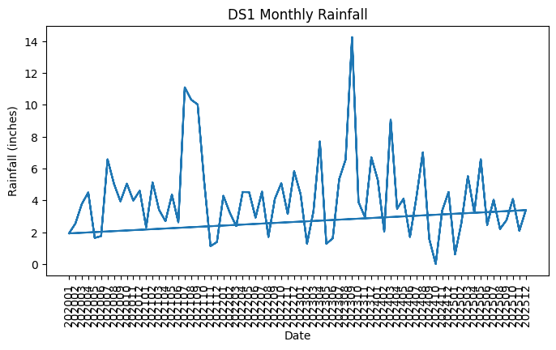

```python
plt.figure(figsize=(8,4))
plt.plot(ds1["Date"].astype(str), ds1["Value"])
plt.title("DS1 Monthly Rainfall")
plt.xlabel("Date")
plt.ylabel("Rainfall (inches)")
plt.xticks(rotation=90)
plt.show()
```

We also examine the distribution of rainfall values using a histogram. This allows us to see how rainfall measurements are spread across the dataset, whether most months fall within a narrow range, and whether there are extreme wet or dry periods. Understanding the rainfall distribution is useful because later analysis may compare accident frequency across lower-rainfall and higher-rainfall periods.

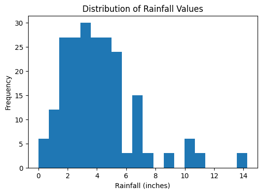

```python
plt.figure(figsize=(6,4))
plt.hist(ds1["Value"].dropna(), bins=20)
plt.title("Distribution of Rainfall Values")
plt.xlabel("Rainfall (inches)")
plt.ylabel("Frequency")
plt.show()
```

**Quality considerations for DS1**

We summarize key quality aspects as follows:

- **Relevancy is strong**, because DS1 directly provides the rainfall measurements needed for the project.
- **Interpretability is strong**, since the dataset has a small and clear schema with `Date`, `Value`, `Anomaly`, and `Station`.
- **Representational consistency is weaker for the main task**, because DS1 is recorded at monthly station level and cannot be directly compared with accident-event data without aggregation and alignment.
- **Amount of data is moderate**, since DS1 is relatively compact and focused only on rainfall measurements rather than broader traffic context.

**Conclusion for DS1**

By itself, DS1 is useful for the project because it contains the core rainfall variable. However, it is not sufficient on its own, since it does not contain accident information and must be integrated with another source for the main analysis.

In light of the above data exploration, we consider DS1 suitable for our analysis with the following caveats, which we will keep in mind during data preparation and analysis:

- DS1 only captures rainfall and does not provide any direct information about accident occurrence or driving conditions.
- Its monthly station-level structure may hide shorter-term rainfall effects that could matter for accident risk.

### DS2: Vehicle accident records dataset profiling

We next load DS2, which contains NYC vehicle accident records. This dataset is central to the project because it provides the accident events that will later be compared against rainfall levels. After loading the file, we preview the first few rows to confirm successful import and get an initial sense of the available accident-related attributes.

```python
ds2 = pd.read_csv("ds2_nyc_crashes.csv")

print("DS2 loaded successfully.")
display(ds2.head())
```

```
DS2 loaded successfully.
```

|  | CRASH DATE | CRASH TIME | BOROUGH | ZIP CODE | LATITUDE | LONGITUDE | LOCATION | ON STREET NAME | CROSS STREET NAME | OFF STREET NAME | ... | CONTRIBUTING FACTOR VEHICLE 2 | CONTRIBUTING FACTOR VEHICLE 3 | CONTRIBUTING FACTOR VEHICLE 4 | CONTRIBUTING FACTOR VEHICLE 5 | COLLISION_ID | VEHICLE TYPE CODE 1 | VEHICLE TYPE CODE 2 | VEHICLE TYPE CODE 3 | VEHICLE TYPE CODE 4 | VEHICLE TYPE CODE 5 |
| --- | --- | --- | --- | --- | --- | --- | --- | --- | --- | --- | --- | --- | --- | --- | --- | --- | --- | --- | --- | --- | --- |
| 0 | 09/11/2021 | 2:39 | NaN | NaN | NaN | NaN | NaN | WHITESTONE EXPRESSWAY | 20 AVENUE | NaN | ... | Unspecified | NaN | NaN | NaN | 4455765 | Sedan | Sedan | NaN | NaN | NaN |
| 1 | 03/26/2022 | 11:45 | NaN | NaN | NaN | NaN | NaN | QUEENSBORO BRIDGE UPPER | NaN | NaN | ... | NaN | NaN | NaN | NaN | 4513547 | Sedan | NaN | NaN | NaN | NaN |
| 2 | 11/01/2023 | 1:29 | BROOKLYN | 11230.0 | 40.62179 | -73.970024 | (40.62179, -73.970024) | OCEAN PARKWAY | AVENUE K | NaN | ... | Unspecified | Unspecified | NaN | NaN | 4675373 | Moped | Sedan | Sedan | NaN | NaN |
| 3 | 06/29/2022 | 6:55 | NaN | NaN | NaN | NaN | NaN | THROGS NECK BRIDGE | NaN | NaN | ... | Unspecified | NaN | NaN | NaN | 4541903 | Sedan | Pick-up Truck | NaN | NaN | NaN |
| 4 | 09/21/2022 | 13:21 | NaN | NaN | NaN | NaN | NaN | BROOKLYN BRIDGE | NaN | NaN | ... | Unspecified | NaN | NaN | NaN | 4566131 | Station Wagon/Sport Utility Vehicle | NaN | NaN | NaN | NaN |

5 rows × 29 columns

```python
explore_dataset(ds2, "DS2")
```

```
===== DS2 OVERVIEW =====
Shape: (2237605, 29)

Columns:
['CRASH DATE', 'CRASH TIME', 'BOROUGH', 'ZIP CODE', 'LATITUDE', 'LONGITUDE', 'LOCATION', 'ON STREET NAME', 'CROSS STREET NAME', 'OFF STREET NAME', 'NUMBER OF PERSONS INJURED', 'NUMBER OF PERSONS KILLED', 'NUMBER OF PEDESTRIANS INJURED', 'NUMBER OF PEDESTRIANS KILLED', 'NUMBER OF CYCLIST INJURED', 'N…

First 5 rows:
```

|  | CRASH DATE | CRASH TIME | BOROUGH | ZIP CODE | LATITUDE | LONGITUDE | LOCATION | ON STREET NAME | CROSS STREET NAME | OFF STREET NAME | ... | CONTRIBUTING FACTOR VEHICLE 2 | CONTRIBUTING FACTOR VEHICLE 3 | CONTRIBUTING FACTOR VEHICLE 4 | CONTRIBUTING FACTOR VEHICLE 5 | COLLISION_ID | VEHICLE TYPE CODE 1 | VEHICLE TYPE CODE 2 | VEHICLE TYPE CODE 3 | VEHICLE TYPE CODE 4 | VEHICLE TYPE CODE 5 |
| --- | --- | --- | --- | --- | --- | --- | --- | --- | --- | --- | --- | --- | --- | --- | --- | --- | --- | --- | --- | --- | --- |
| 0 | 09/11/2021 | 2:39 | NaN | NaN | NaN | NaN | NaN | WHITESTONE EXPRESSWAY | 20 AVENUE | NaN | ... | Unspecified | NaN | NaN | NaN | 4455765 | Sedan | Sedan | NaN | NaN | NaN |
| 1 | 03/26/2022 | 11:45 | NaN | NaN | NaN | NaN | NaN | QUEENSBORO BRIDGE UPPER | NaN | NaN | ... | NaN | NaN | NaN | NaN | 4513547 | Sedan | NaN | NaN | NaN | NaN |
| 2 | 11/01/2023 | 1:29 | BROOKLYN | 11230.0 | 40.62179 | -73.970024 | (40.62179, -73.970024) | OCEAN PARKWAY | AVENUE K | NaN | ... | Unspecified | Unspecified | NaN | NaN | 4675373 | Moped | Sedan | Sedan | NaN | NaN |
| 3 | 06/29/2022 | 6:55 | NaN | NaN | NaN | NaN | NaN | THROGS NECK BRIDGE | NaN | NaN | ... | Unspecified | NaN | NaN | NaN | 4541903 | Sedan | Pick-up Truck | NaN | NaN | NaN |
| 4 | 09/21/2022 | 13:21 | NaN | NaN | NaN | NaN | NaN | BROOKLYN BRIDGE | NaN | NaN | ... | Unspecified | NaN | NaN | NaN | 4566131 | Station Wagon/Sport Utility Vehicle | NaN | NaN | NaN | NaN |

5 rows × 29 columns

```
Data types:
```

|  | 0 |
| --- | --- |
| CRASH DATE | object |
| CRASH TIME | object |
| BOROUGH | object |
| ZIP CODE | object |
| LATITUDE | float64 |
| LONGITUDE | float64 |
| LOCATION | object |
| ON STREET NAME | object |
| CROSS STREET NAME | object |
| OFF STREET NAME | object |
| NUMBER OF PERSONS INJURED | float64 |
| NUMBER OF PERSONS KILLED | float64 |
| NUMBER OF PEDESTRIANS INJURED | int64 |
| NUMBER OF PEDESTRIANS KILLED | int64 |
| NUMBER OF CYCLIST INJURED | int64 |
| NUMBER OF CYCLIST KILLED | int64 |
| NUMBER OF MOTORIST INJURED | int64 |
| NUMBER OF MOTORIST KILLED | int64 |
| CONTRIBUTING FACTOR VEHICLE 1 | object |
| CONTRIBUTING FACTOR VEHICLE 2 | object |
| CONTRIBUTING FACTOR VEHICLE 3 | object |
| CONTRIBUTING FACTOR VEHICLE 4 | object |
| CONTRIBUTING FACTOR VEHICLE 5 | object |
| COLLISION_ID | int64 |
| VEHICLE TYPE CODE 1 | object |
| VEHICLE TYPE CODE 2 | object |
| VEHICLE TYPE CODE 3 | object |
| VEHICLE TYPE CODE 4 | object |
| VEHICLE TYPE CODE 5 | object |

**dtype:** object

```
Missing values:
```

|  | Missing Count |
| --- | --- |
| CRASH DATE | 0 |
| CRASH TIME | 0 |
| BOROUGH | 683713 |
| ZIP CODE | 683994 |
| LATITUDE | 240550 |
| LONGITUDE | 240550 |
| LOCATION | 240550 |
| ON STREET NAME | 488856 |
| CROSS STREET NAME | 855318 |
| OFF STREET NAME | 1841123 |
| NUMBER OF PERSONS INJURED | 18 |
| NUMBER OF PERSONS KILLED | 31 |
| NUMBER OF PEDESTRIANS INJURED | 0 |
| NUMBER OF PEDESTRIANS KILLED | 0 |
| NUMBER OF CYCLIST INJURED | 0 |
| NUMBER OF CYCLIST KILLED | 0 |
| NUMBER OF MOTORIST INJURED | 0 |
| NUMBER OF MOTORIST KILLED | 0 |
| CONTRIBUTING FACTOR VEHICLE 1 | 8013 |
| CONTRIBUTING FACTOR VEHICLE 2 | 361283 |
| CONTRIBUTING FACTOR VEHICLE 3 | 2075614 |
| CONTRIBUTING FACTOR VEHICLE 4 | 2200582 |
| CONTRIBUTING FACTOR VEHICLE 5 | 2227459 |
| COLLISION_ID | 0 |
| VEHICLE TYPE CODE 1 | 16533 |
| VEHICLE TYPE CODE 2 | 451936 |
| VEHICLE TYPE CODE 3 | 2081968 |
| VEHICLE TYPE CODE 4 | 2201929 |
| VEHICLE TYPE CODE 5 | 2227780 |

```
Duplicate rows: 0

Summary statistics:
```

|  | CRASH DATE | CRASH TIME | BOROUGH | ZIP CODE | LATITUDE | LONGITUDE | LOCATION | ON STREET NAME | CROSS STREET NAME | OFF STREET NAME | ... | CONTRIBUTING FACTOR VEHICLE 2 | CONTRIBUTING FACTOR VEHICLE 3 | CONTRIBUTING FACTOR VEHICLE 4 | CONTRIBUTING FACTOR VEHICLE 5 | COLLISION_ID | VEHICLE TYPE CODE 1 | VEHICLE TYPE CODE 2 | VEHICLE TYPE CODE 3 | VEHICLE TYPE CODE 4 | VEHICLE TYPE CODE 5 |
| --- | --- | --- | --- | --- | --- | --- | --- | --- | --- | --- | --- | --- | --- | --- | --- | --- | --- | --- | --- | --- | --- |
| count | 2237605 | 2237605 | 1553892 | 1553611.0 | 1.997055e+06 | 1.997055e+06 | 1997055 | 1748749 | 1382287 | 396482 | ... | 1876322 | 161991 | 37023 | 10146 | 2.237605e+06 | 2221072 | 1785669 | 155637 | 35676 | 9825 |
| unique | 4957 | 1440 | 5 | 437.0 | NaN | NaN | 339388 | 22982 | 25067 | 263519 | ... | 61 | 53 | 43 | 34 | NaN | 1855 | 2065 | 300 | 116 | 78 |
| top | 01/21/2014 | 16:00 | BROOKLYN | 11207.0 | NaN | NaN | (0.0, 0.0) | BROADWAY | 3 AVENUE | 772 EDGEWATER ROAD | ... | Unspecified | Unspecified | Unspecified | Unspecified | NaN | Sedan | Sedan | Sedan | Sedan | Sedan |
| freq | 1161 | 29841 | 498482 | 23577.0 | NaN | NaN | 6870 | 17277 | 9843 | 402 | ... | 1578644 | 150863 | 34888 | 9553 | NaN | 649679 | 445334 | 50546 | 12383 | 3561 |
| mean | NaN | NaN | NaN | NaN | 4.058377e+01 | -7.367220e+01 | NaN | NaN | NaN | NaN | ... | NaN | NaN | NaN | NaN | 3.278018e+06 | NaN | NaN | NaN | NaN | NaN |
| std | NaN | NaN | NaN | NaN | 2.385756e+00 | 4.429263e+00 | NaN | NaN | NaN | NaN | ... | NaN | NaN | NaN | NaN | 1.510234e+06 | NaN | NaN | NaN | NaN | NaN |
| min | NaN | NaN | NaN | NaN | 0.000000e+00 | -2.013600e+02 | NaN | NaN | NaN | NaN | ... | NaN | NaN | NaN | NaN | 2.200000e+01 | NaN | NaN | NaN | NaN | NaN |
| 25% | NaN | NaN | NaN | NaN | 4.066731e+01 | -7.397451e+01 | NaN | NaN | NaN | NaN | ... | NaN | NaN | NaN | NaN | 3.195522e+06 | NaN | NaN | NaN | NaN | NaN |
| 50% | NaN | NaN | NaN | NaN | 4.072025e+01 | -7.392667e+01 | NaN | NaN | NaN | NaN | ... | NaN | NaN | NaN | NaN | 3.755105e+06 | NaN | NaN | NaN | NaN | NaN |
| 75% | NaN | NaN | NaN | NaN | 4.076958e+01 | -7.386650e+01 | NaN | NaN | NaN | NaN | ... | NaN | NaN | NaN | NaN | 4.314714e+06 | NaN | NaN | NaN | NaN | NaN |
| max | NaN | NaN | NaN | NaN | 4.334444e+01 | 0.000000e+00 | NaN | NaN | NaN | NaN | ... | NaN | NaN | NaN | NaN | 4.874393e+06 | NaN | NaN | NaN | NaN | NaN |

11 rows × 29 columns

We then inspect some key fields more closely. The borough values confirm that the accident records cover the five NYC boroughs: Brooklyn, Bronx, Manhattan, Queens, and Staten Island. We also check the number of unique collision IDs and find that nearly every row corresponds to a distinct accident record, which is suitable for event-level analysis. Finally, we preview the crash date and crash time columns to verify that DS2 contains the temporal information needed to align accidents with rainfall observations.

```python
print("Unique BOROUGH values:")
print(ds2["BOROUGH"].dropna().unique())

print("\nNumber of unique COLLISION_ID:")
print(ds2["COLLISION_ID"].nunique())

print("\nDate and time preview:")
display(ds2[["CRASH DATE", "CRASH TIME"]].head(10))
```

```
Unique BOROUGH values:
['BROOKLYN' 'BRONX' 'MANHATTAN' 'QUEENS' 'STATEN ISLAND']

Number of unique COLLISION_ID:
2237605

Date and time preview:
```

|  | CRASH DATE | CRASH TIME |
| --- | --- | --- |
| 0 | 09/11/2021 | 2:39 |
| 1 | 03/26/2022 | 11:45 |
| 2 | 11/01/2023 | 1:29 |
| 3 | 06/29/2022 | 6:55 |
| 4 | 09/21/2022 | 13:21 |
| 5 | 04/26/2023 | 13:30 |
| 6 | 11/01/2023 | 7:12 |
| 7 | 11/01/2023 | 8:01 |
| 8 | 04/26/2023 | 22:20 |
| 9 | 09/11/2021 | 9:35 |

```python
ds2["CRASH DATE"] = pd.to_datetime(ds2["CRASH DATE"], errors="coerce")

print("Crash date range:")
print("Min date:", ds2["CRASH DATE"].min())
print("Max date:", ds2["CRASH DATE"].max())
```

```
Crash date range:
Min date: 2012-07-01 00:00:00
Max date: 2026-01-25 00:00:00
```

We visualise the frequency of records across boroughs to understand how the accident data is distributed geographically. This helps us assess whether some boroughs contribute substantially more accidents than others. Since location consistency matters for integrating rainfall and accident data, identifying the borough distribution is useful for deciding whether to analyse the whole dataset or focus on specific areas.

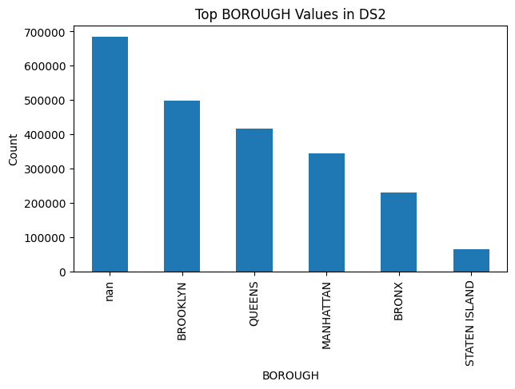

```python
plt.figure(figsize=(7,4))
ds2["BOROUGH"].value_counts(dropna=False).head(10).plot(kind="bar")
plt.title("Top BOROUGH Values in DS2")
plt.ylabel("Count")
plt.show()
```

We plot the most common contributing factors recorded for vehicle 1 to better understand the accident context in DS2. This gives a quick overview of the major reported causes or associated factors behind crashes. Although contributing factors are not the main variable for our rainfall analysis, they provide useful context and may help explain variation in accident counts beyond weather alone.

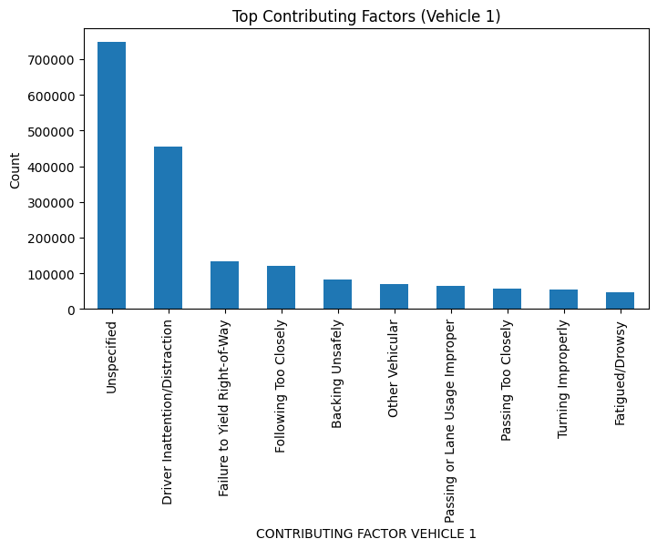

```python
plt.figure(figsize=(8,4))
ds2["CONTRIBUTING FACTOR VEHICLE 1"].value_counts(dropna=False).head(10).plot(kind="bar")
plt.title("Top Contributing Factors (Vehicle 1)")
plt.ylabel("Count")
plt.show()
```

We also examine the most common vehicle types involved in the accident records. This helps us understand the general composition of traffic in the dataset and whether certain vehicle categories dominate the accidents. While vehicle type is not the primary focus of the research question, it adds descriptive context and may be useful when interpreting accident trends later.

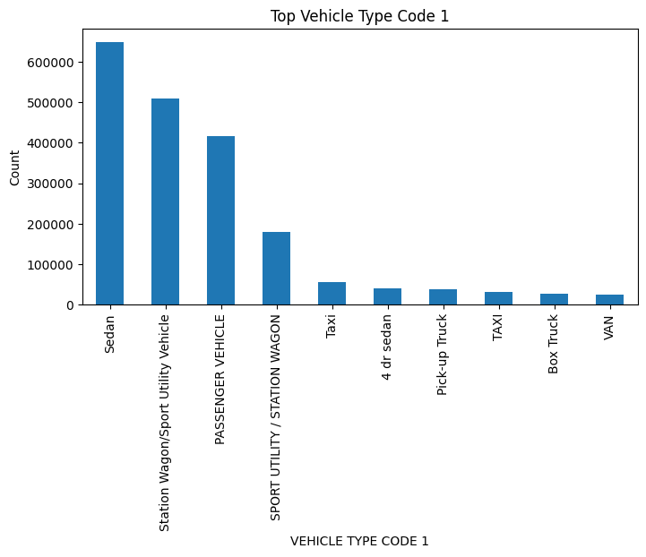

```python
plt.figure(figsize=(8,4))
ds2["VEHICLE TYPE CODE 1"].value_counts(dropna=False).head(10).plot(kind="bar")
plt.title("Top Vehicle Type Code 1")
plt.ylabel("Count")
plt.show()
```

**Quality considerations for DS2**

We summarize key quality aspects as follows:

- **Relevancy is very strong**, because DS2 is the main accident dataset used to measure vehicle accident occurrence.
- **Amount of data is strong**, since DS2 contains a large number of accident records and multiple accident-related attributes.
- **Value-added is strong**, because it includes time, location, injuries, fatalities, and other accident-related details.
- **Representational consistency is weaker for direct integration**, because DS2 is event-level data and must first be aggregated to match DS1’s monthly station-level structure.
- **Timeliness is mixed**, because DS2 covers a longer period than DS1, which means part of its coverage cannot be used in the final merged analysis.

**Conclusion for DS2**

By itself, DS2 is a strong source for accident analysis, but it is not sufficient for answering the project question because it does not contain rainfall measurements. It is therefore most useful when integrated with DS1.

In light of the above data exploration, we consider DS2 suitable for our analysis with the following caveats, which we will keep in mind during data preparation and analysis:

- Aggregation choices may affect the final result, since the raw dataset is more detailed than the rainfall source.
- Some of DS2’s wider time coverage is lost during integration because the rainfall data does not cover the full same period.

### DS3: Road traffic accident dataset profiling

We then load DS3, a road traffic accident dataset from Kaggle. Because the file contains non-standard text encoding, it is read using `latin1` to avoid decoding errors. After loading the dataset, we preview the first few rows to confirm that the data was imported correctly and to inspect the format of the accident-related fields.

```python
ds3 = pd.read_csv("ds3_road_traffic_accidents_2018.csv", encoding="latin1")

print("DS3 loaded successfully")
display(ds3.head())
```

```
DS3 loaded successfully
```

|  | Reference Number | Easting | Northing | Number of Vehicles | Accident Date | Time (24hr) | 1st Road Class | Road Surface | Lighting Conditions | Weather Conditions | ... | Type of Vehicle 5 | Casualty Class 5 | Casualty Severity 5 | Sex of Casualty 5 | Age of Casualty 5 | Type of Vehicle 6 | Casualty Class 6 | Casualty Severity 6 | Sex of Casualty 6 | Age of Casualty 6 |
| --- | --- | --- | --- | --- | --- | --- | --- | --- | --- | --- | --- | --- | --- | --- | --- | --- | --- | --- | --- | --- | --- |
| 0 | 5131732 | 415809 | 422277 | 2 | 03/01/2018 | 2054 | Unclassified | Wet / Damp | Darkness: street lights present and lit | Raining without high winds | ... | NaN | NaN | NaN | NaN | NaN | NaN | NaN | NaN | NaN | NaN |
| 1 | 5140196 | 414478 | 422719 | 2 | 04/01/2018 | 551 | A | Wet / Damp | Darkness: street lights present and lit | Raining without high winds | ... | NaN | NaN | NaN | NaN | NaN | NaN | NaN | NaN | NaN | NaN |
| 2 | 5151479 | 411718 | 427905 | 2 | 05/01/2018 | 1650 | Unclassified | Wet / Damp | Darkness: street lights present and lit | Fine without high winds | ... | NaN | NaN | NaN | NaN | NaN | NaN | NaN | NaN | NaN | NaN |
| 3 | 51A0239 | 409779 | 425728 | 2 | 10/01/2018 | 744 | A | Wet / Damp | Daylight: street lights present | Fine without high winds | ... | NaN | NaN | NaN | NaN | NaN | NaN | NaN | NaN | NaN | NaN |
| 4 | 5.10E+227 | 416632 | 422355 | 4 | 14/01/2018 | 348 | Motorway | Wet / Damp | Darkness: street lighting unknown | Fine without high winds | ... | NaN | Vehicle or pillion passenger | Slight | Male | 40 | NaN | NaN | NaN | NaN | NaN |

5 rows × 40 columns

```python
# Select useful columns
ds3_prepared = ds3[[
    "Accident Date",
    "Time (24hr)",
    "Weather Conditions",
    "Road Surface",
    "Lighting Conditions",
    "1st Road Class"
]].copy()

print("DS3 shape after column selection:", ds3_prepared.shape)
display(ds3_prepared.head())
```

```
DS3 shape after column selection: (314, 6)
```

|  | Accident Date | Time (24hr) | Weather Conditions | Road Surface | Lighting Conditions | 1st Road Class |
| --- | --- | --- | --- | --- | --- | --- |
| 0 | 03/01/2018 | 2054 | Raining without high winds | Wet / Damp | Darkness: street lights present and lit | Unclassified |
| 1 | 04/01/2018 | 551 | Raining without high winds | Wet / Damp | Darkness: street lights present and lit | A |
| 2 | 05/01/2018 | 1650 | Fine without high winds | Wet / Damp | Darkness: street lights present and lit | Unclassified |
| 3 | 10/01/2018 | 744 | Fine without high winds | Wet / Damp | Daylight: street lights present | A |
| 4 | 14/01/2018 | 348 | Fine without high winds | Wet / Damp | Darkness: street lighting unknown | Motorway |

We explore the overall structure of DS3 to evaluate its usefulness for the project. From the output, DS3 contains 314 rows and 40 columns, making it much smaller than DS2 but richer in contextual accident details. The columns include accident date, time, road class, road surface, lighting conditions, weather conditions, number of vehicles, and multiple casualty-related fields. This suggests that DS3 may be more suitable as a supporting dataset for contextual analysis or methodological comparison rather than as the main dataset for integration with rainfall.

```python
explore_dataset(ds3, "DS3")
```

```
===== DS3 OVERVIEW =====
Shape: (314, 40)

Columns:
['Reference Number', 'Easting', 'Northing', 'Number of Vehicles', 'Accident Date', 'Time (24hr)', '1st Road Class', 'Road Surface', 'Lighting Conditions', 'Weather Conditions', 'Type of Vehicle 1', 'Casualty Class 1', 'Casualty Severity 1', 'Sex of Casualty 1', 'Age of Casualty 1', 'Type of Vehicle …

First 5 rows:
```

|  | Reference Number | Easting | Northing | Number of Vehicles | Accident Date | Time (24hr) | 1st Road Class | Road Surface | Lighting Conditions | Weather Conditions | ... | Type of Vehicle 5 | Casualty Class 5 | Casualty Severity 5 | Sex of Casualty 5 | Age of Casualty 5 | Type of Vehicle 6 | Casualty Class 6 | Casualty Severity 6 | Sex of Casualty 6 | Age of Casualty 6 |
| --- | --- | --- | --- | --- | --- | --- | --- | --- | --- | --- | --- | --- | --- | --- | --- | --- | --- | --- | --- | --- | --- |
| 0 | 5131732 | 415809 | 422277 | 2 | 03/01/2018 | 2054 | Unclassified | Wet / Damp | Darkness: street lights present and lit | Raining without high winds | ... | NaN | NaN | NaN | NaN | NaN | NaN | NaN | NaN | NaN | NaN |
| 1 | 5140196 | 414478 | 422719 | 2 | 04/01/2018 | 551 | A | Wet / Damp | Darkness: street lights present and lit | Raining without high winds | ... | NaN | NaN | NaN | NaN | NaN | NaN | NaN | NaN | NaN | NaN |
| 2 | 5151479 | 411718 | 427905 | 2 | 05/01/2018 | 1650 | Unclassified | Wet / Damp | Darkness: street lights present and lit | Fine without high winds | ... | NaN | NaN | NaN | NaN | NaN | NaN | NaN | NaN | NaN | NaN |
| 3 | 51A0239 | 409779 | 425728 | 2 | 10/01/2018 | 744 | A | Wet / Damp | Daylight: street lights present | Fine without high winds | ... | NaN | NaN | NaN | NaN | NaN | NaN | NaN | NaN | NaN | NaN |
| 4 | 5.10E+227 | 416632 | 422355 | 4 | 14/01/2018 | 348 | Motorway | Wet / Damp | Darkness: street lighting unknown | Fine without high winds | ... | NaN | Vehicle or pillion passenger | Slight | Male | 40 | NaN | NaN | NaN | NaN | NaN |

5 rows × 40 columns

```
Data types:
```

|  | 0 |
| --- | --- |
| Reference Number | object |
| Easting | int64 |
| Northing | int64 |
| Number of Vehicles | int64 |
| Accident Date | object |
| Time (24hr) | int64 |
| 1st Road Class | object |
| Road Surface | object |
| Lighting Conditions | object |
| Weather Conditions | object |
| Type of Vehicle 1 | object |
| Casualty Class 1 | object |
| Casualty Severity 1 | object |
| Sex of Casualty 1 | object |
| Age of Casualty 1 | int64 |
| Type of Vehicle 2 | object |
| Casualty Class 2 | object |
| Casualty Severity 2 | object |
| Sex of Casualty 2 | object |
| Age of Casualty 2 | object |
| Type of Vehicle 3 | object |
| Casualty Class 3 | object |
| Casualty Severity 3 | object |
| Sex of Casualty 3 | object |
| Age of Casualty 3 | object |
| Type of Vehicle 4 | object |
| Casualty Class 4 | object |
| Casualty Severity 4 | object |
| Sex of Casualty 4 | object |
| Age of Casualty 4 | object |
| Type of Vehicle 5 | object |
| Casualty Class 5 | object |
| Casualty Severity 5 | object |
| Sex of Casualty 5 | object |
| Age of Casualty 5 | object |
| Type of Vehicle 6 | object |
| Casualty Class 6 | object |
| Casualty Severity 6 | object |
| Sex of Casualty 6 | object |
| Age of Casualty 6 | object |

**dtype:** object

```
Missing values:
```

|  | Missing Count |
| --- | --- |
| Reference Number | 0 |
| Easting | 0 |
| Northing | 0 |
| Number of Vehicles | 0 |
| Accident Date | 0 |
| Time (24hr) | 0 |
| 1st Road Class | 0 |
| Road Surface | 0 |
| Lighting Conditions | 0 |
| Weather Conditions | 0 |
| Type of Vehicle 1 | 0 |
| Casualty Class 1 | 0 |
| Casualty Severity 1 | 0 |
| Sex of Casualty 1 | 0 |
| Age of Casualty 1 | 0 |
| Type of Vehicle 2 | 101 |
| Casualty Class 2 | 92 |
| Casualty Severity 2 | 92 |
| Sex of Casualty 2 | 92 |
| Age of Casualty 2 | 92 |
| Type of Vehicle 3 | 280 |
| Casualty Class 3 | 264 |
| Casualty Severity 3 | 264 |
| Sex of Casualty 3 | 264 |
| Age of Casualty 3 | 264 |
| Type of Vehicle 4 | 303 |
| Casualty Class 4 | 298 |
| Casualty Severity 4 | 298 |
| Sex of Casualty 4 | 298 |
| Age of Casualty 4 | 298 |
| Type of Vehicle 5 | 311 |
| Casualty Class 5 | 307 |
| Casualty Severity 5 | 307 |
| Sex of Casualty 5 | 307 |
| Age of Casualty 5 | 307 |
| Type of Vehicle 6 | 312 |
| Casualty Class 6 | 310 |
| Casualty Severity 6 | 310 |
| Sex of Casualty 6 | 310 |
| Age of Casualty 6 | 310 |

```
Duplicate rows: 0

Summary statistics:
```

|  | Reference Number | Easting | Northing | Number of Vehicles | Accident Date | Time (24hr) | 1st Road Class | Road Surface | Lighting Conditions | Weather Conditions | ... | Type of Vehicle 5 | Casualty Class 5 | Casualty Severity 5 | Sex of Casualty 5 | Age of Casualty 5 | Type of Vehicle 6 | Casualty Class 6 | Casualty Severity 6 | Sex of Casualty 6 | Age of Casualty 6 |
| --- | --- | --- | --- | --- | --- | --- | --- | --- | --- | --- | --- | --- | --- | --- | --- | --- | --- | --- | --- | --- | --- |
| count | 314 | 314.000000 | 314.000000 | 314.000000 | 314 | 314.000000 | 314 | 314 | 314 | 314 | ... | 3 | 7 | 7 | 7 | 7 | 2 | 4 | 4 | 4 | 4 |
| unique | 314 | NaN | NaN | NaN | 212 | NaN | 4 | 4 | 5 | 8 | ... | 2 | 3 | 2 | 3 | 5 | 2 | 2 | 2 | 3 | 3 |
| top | 6121478 | NaN | NaN | NaN | 16/01/2018 | NaN | Unclassified | Dry | Daylight: street lights present | Fine without high winds | ... | Goods vehicle 3.5 tonnes mgw and under | not known | Slight | Male | not known | Goods vehicle 7.5 tonnes mgw and over | not known | not known | not known | not known |
| freq | 1 | NaN | NaN | NaN | 4 | NaN | 154 | 221 | 229 | 258 | ... | 2 | 3 | 4 | 3 | 3 | 1 | 2 | 2 | 2 | 2 |
| mean | NaN | 407884.987261 | 423757.891720 | 1.837580 | NaN | 1358.834395 | NaN | NaN | NaN | NaN | ... | NaN | NaN | NaN | NaN | NaN | NaN | NaN | NaN | NaN | NaN |
| std | NaN | 5711.996403 | 3079.962795 | 0.776485 | NaN | 513.513380 | NaN | NaN | NaN | NaN | ... | NaN | NaN | NaN | NaN | NaN | NaN | NaN | NaN | NaN | NaN |
| min | NaN | 390809.000000 | 414672.000000 | 1.000000 | NaN | 20.000000 | NaN | NaN | NaN | NaN | ... | NaN | NaN | NaN | NaN | NaN | NaN | NaN | NaN | NaN | NaN |
| 25% | NaN | 405900.000000 | 422480.000000 | 1.000000 | NaN | 955.750000 | NaN | NaN | NaN | NaN | ... | NaN | NaN | NaN | NaN | NaN | NaN | NaN | NaN | NaN | NaN |
| 50% | NaN | 408479.000000 | 424157.000000 | 2.000000 | NaN | 1427.000000 | NaN | NaN | NaN | NaN | ... | NaN | NaN | NaN | NaN | NaN | NaN | NaN | NaN | NaN | NaN |
| 75% | NaN | 411569.250000 | 425572.500000 | 2.000000 | NaN | 1728.750000 | NaN | NaN | NaN | NaN | ... | NaN | NaN | NaN | NaN | NaN | NaN | NaN | NaN | NaN | NaN |
| max | NaN | 417825.000000 | 430737.000000 | 6.000000 | NaN | 2359.000000 | NaN | NaN | NaN | NaN | ... | NaN | NaN | NaN | NaN | NaN | NaN | NaN | NaN | NaN | NaN |

11 rows × 40 columns

We inspect sample values from the reference number, accident date, and time columns to better understand the raw data format. The reference numbers appear in mixed formats, including standard-looking IDs and scientific-notation-like values, which suggests that this field may need careful handling if used as an identifier. The accident date values are stored in day-first string format, while the time values are written in compact 24-hour notation such as `2054`, `551`, and `744`. This confirms that date and time standardisation will be necessary during preparation.

```python
print("Reference Number examples:")
print(ds3["Reference Number"].astype(str).head(10).tolist())

print("\nAccident Date examples:")
print(ds3["Accident Date"].astype(str).head(10).tolist())

print("\nTime (24hr) examples:")
print(ds3["Time (24hr)"].astype(str).head(10).tolist())
```

```
Reference Number examples:
['5131732', '5140196', '5151479', '51A0239', '5.10E+227', '51E0855', '51E1541', '51E1807', '51G0202', '51G0210']

Accident Date examples:
['03/01/2018', '04/01/2018', '05/01/2018', '10/01/2018', '14/01/2018', '14/01/2018', '14/01/2018', '14/01/2018', '16/01/2018', '16/01/2018']

Time (24hr) examples:
['2054', '551', '1650', '744', '348', '1325', '1915', '2030', '714', '630']
```

We convert the `Accident Date` column into datetime format using day-first parsing. This allows us to work with the accident dates more reliably in later preparation steps. From the output, the accident records span from 3 January 2018 to 31 December 2018, confirming that DS3 is limited to a single calendar year. Because of this narrower coverage, DS3 is less suitable as the main integrated source compared with DS2, but it remains useful for supplementary insights.

```python
ds3["Accident Date"] = pd.to_datetime(ds3["Accident Date"], dayfirst=True, errors="coerce")

print("Accident date range:")
print("Min date:", ds3["Accident Date"].min())
print("Max date:", ds3["Accident Date"].max())
```

```
Accident date range:
Min date: 2018-01-03 00:00:00
Max date: 2018-12-31 00:00:00
```

We examine the number of missing values in each DS3 column to assess data completeness. The output shows that many of the missing values occur in columns related to the fourth, fifth, and sixth vehicles or casualties, which is expected because not every accident involves many vehicles or many casualties. In contrast, the key contextual fields such as accident date, time, road class, road surface, lighting conditions, and weather conditions appear much more complete. This indicates that DS3 can still support analysis if we focus on the main accident-level variables rather than the higher-order casualty fields.

```python
ds3_missing = ds3.isnull().sum().sort_values(ascending=False)
display(ds3_missing.to_frame("Missing Count"))
```

|  | Missing Count |
| --- | --- |
| Type of Vehicle 6 | 312 |
| Type of Vehicle 5 | 311 |
| Sex of Casualty 6 | 310 |
| Casualty Severity 6 | 310 |
| Casualty Class 6 | 310 |
| Age of Casualty 6 | 310 |
| Age of Casualty 5 | 307 |
| Casualty Class 5 | 307 |
| Sex of Casualty 5 | 307 |
| Casualty Severity 5 | 307 |
| Type of Vehicle 4 | 303 |
| Casualty Class 4 | 298 |
| Sex of Casualty 4 | 298 |
| Age of Casualty 4 | 298 |
| Casualty Severity 4 | 298 |
| Type of Vehicle 3 | 280 |
| Casualty Class 3 | 264 |
| Sex of Casualty 3 | 264 |
| Casualty Severity 3 | 264 |
| Age of Casualty 3 | 264 |
| Type of Vehicle 2 | 101 |
| Age of Casualty 2 | 92 |
| Casualty Severity 2 | 92 |
| Sex of Casualty 2 | 92 |
| Casualty Class 2 | 92 |
| 1st Road Class | 0 |
| Time (24hr) | 0 |
| Accident Date | 0 |
| Number of Vehicles | 0 |
| Northing | 0 |
| Easting | 0 |
| Reference Number | 0 |
| Road Surface | 0 |
| Casualty Class 1 | 0 |
| Type of Vehicle 1 | 0 |
| Lighting Conditions | 0 |
| Sex of Casualty 1 | 0 |
| Casualty Severity 1 | 0 |
| Age of Casualty 1 | 0 |
| Weather Conditions | 0 |

We inspect the most common values in several key categorical columns, including road class, road surface, lighting conditions, weather conditions, vehicle type, and casualty-related fields. This gives a better sense of the dominant accident contexts represented in DS3. Looking at category frequencies also helps identify whether any variables have too many rare categories, inconsistent labels, or potentially uninformative values that may require consolidation during preparation.

```python
for col in [
    "1st Road Class", "Road Surface", "Lighting Conditions",
    "Weather Conditions", "Type of Vehicle 1",
    "Casualty Class 1", "Casualty Severity 1", "Sex of Casualty 1"
]:
    if col in ds3.columns:
        print(f"\nTop values for {col}:")
        display(ds3[col].value_counts(dropna=False).head(10))
```

```
Top values for 1st Road Class:
```

| 1st Road Class | count |
| --- | --- |
| Unclassified | 154 |
| A | 124 |
| Motorway | 29 |
| B | 7 |

**dtype:** int64

```
Top values for Road Surface:
```

| Road Surface | count |
| --- | --- |
| Dry | 221 |
| Wet / Damp | 78 |
| Snow | 11 |
| Frost / Ice | 4 |

**dtype:** int64

```
Top values for Lighting Conditions:
```

| Lighting Conditions | count |
| --- | --- |
| Daylight: street lights present | 229 |
| Darkness: street lights present and lit | 74 |
| Darkness: no street lighting | 5 |
| Darkness: street lighting unknown | 4 |
| Darkness: street lights present but unlit | 2 |

**dtype:** int64

```
Top values for Weather Conditions:
```

| Weather Conditions | count |
| --- | --- |
| Fine without high winds | 258 |
| Raining without high winds | 35 |
| Snowing without high winds | 7 |
| Other | 3 |
| Fine with high winds | 3 |
| Snowing with high winds | 3 |
| Fog or mist  if hazard | 3 |
| Raining with high winds | 2 |

**dtype:** int64

```
Top values for Type of Vehicle 1:
```

| Type of Vehicle 1 | count |
| --- | --- |
| Car | 238 |
| Goods vehicle 3.5 tonnes mgw and under | 17 |
| Pedal cycle | 14 |
| Taxi/Private hire car | 12 |
| Motorcycle over 50cc and up to 125cc | 9 |
| Bus or coach (17 or more passenger seats) | 6 |
| Motorcycle over 500cc | 5 |
| Goods vehicle 7.5 tonnes mgw and over | 4 |
| Motorcycle over 125cc and up to 500cc | 3 |
| M/cycle 50cc and under | 2 |

**dtype:** int64

```
Top values for Casualty Class 1:
```

| Casualty Class 1 | count |
| --- | --- |
| Driver or rider | 204 |
| Pedestrian | 70 |
| Vehicle or pillion passenger | 40 |

**dtype:** int64

```
Top values for Casualty Severity 1:
```

| Casualty Severity 1 | count |
| --- | --- |
| Slight | 253 |
| Serious | 57 |
| Fatal | 4 |

**dtype:** int64

```
Top values for Sex of Casualty 1:
```

| Sex of Casualty 1 | count |
| --- | --- |
| Male | 191 |
| Female | 123 |

**dtype:** int64

We visualise the most common weather conditions recorded in DS3 to understand the weather context of these accidents. Since the research question focuses on rainfall and accident occurrence, this chart is particularly useful for checking whether rainy conditions are meaningfully represented in the dataset. Even if DS3 is not used as the primary merged source, the weather distribution still provides useful comparison and supporting context.

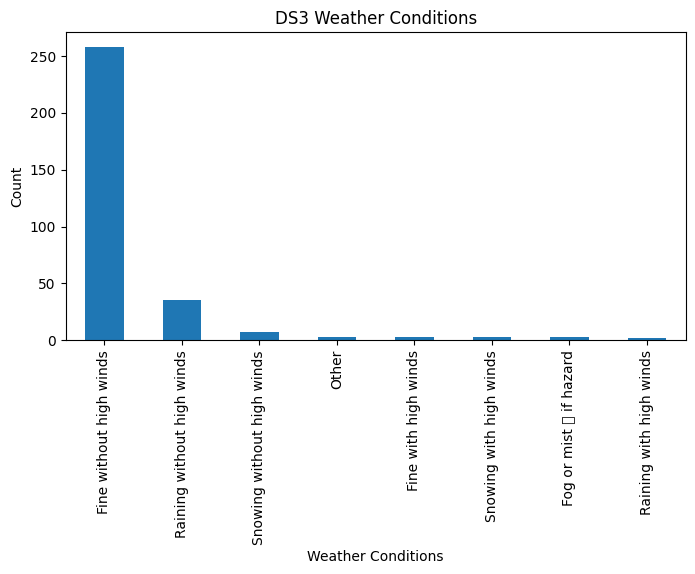

```python
plt.figure(figsize=(8,4))
ds3["Weather Conditions"].value_counts(dropna=False).head(10).plot(kind="bar")
plt.title("DS3 Weather Conditions")
plt.ylabel("Count")
plt.show()
```

We plot the distribution of road surface categories in DS3 to examine the types of surface conditions under which accidents occurred. Road surface is relevant because wet or slippery roads may be associated with rainfall-related risk. This variable may therefore be useful later as a supporting contextual feature when discussing how rainfall could influence accident outcomes.

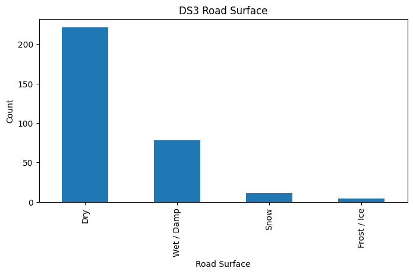

```python
plt.figure(figsize=(8,4))
ds3["Road Surface"].value_counts(dropna=False).head(10).plot(kind="bar")
plt.title("DS3 Road Surface")
plt.ylabel("Count")
plt.show()
```

We also examine the distribution of lighting conditions in DS3. Lighting may affect visibility and accident risk, so it is a useful contextual variable even though it is not the main explanatory factor in our study. By exploring this distribution, we gain a better overall understanding of the accident environment captured in the dataset.

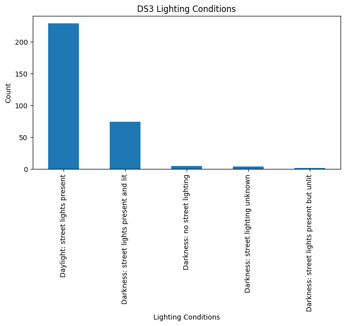

```python
plt.figure(figsize=(8,4))
ds3["Lighting Conditions"].value_counts(dropna=False).head(10).plot(kind="bar")
plt.title("DS3 Lighting Conditions")
plt.ylabel("Count")
plt.show()
```

Finally, we specifically inspect the missingness of casualty-related columns in DS3. The output shows that information for the first casualty is mostly complete, while details for later casualties are increasingly sparse. This pattern is expected because many accidents do not involve multiple casualties. As a result, if DS3 is used later, the analysis should focus on the first casualty or on aggregate accident-level variables instead of relying heavily on casualty fields for the later positions.

```python
casualty_cols = [col for col in ds3.columns if "Casualty" in col or "Sex of Casualty" in col or "Age of Casualty" in col]
display(ds3[casualty_cols].isnull().sum().sort_values(ascending=False).to_frame("Missing Count"))
```

|  | Missing Count |
| --- | --- |
| Age of Casualty 6 | 310 |
| Sex of Casualty 6 | 310 |
| Casualty Severity 6 | 310 |
| Casualty Class 6 | 310 |
| Age of Casualty 5 | 307 |
| Sex of Casualty 5 | 307 |
| Casualty Severity 5 | 307 |
| Casualty Class 5 | 307 |
| Casualty Class 4 | 298 |
| Casualty Severity 4 | 298 |
| Sex of Casualty 4 | 298 |
| Age of Casualty 4 | 298 |
| Casualty Class 3 | 264 |
| Casualty Severity 3 | 264 |
| Sex of Casualty 3 | 264 |
| Age of Casualty 3 | 264 |
| Casualty Class 2 | 92 |
| Casualty Severity 2 | 92 |
| Sex of Casualty 2 | 92 |
| Age of Casualty 2 | 92 |
| Casualty Class 1 | 0 |
| Casualty Severity 1 | 0 |
| Sex of Casualty 1 | 0 |
| Age of Casualty 1 | 0 |

**Quality considerations for DS3**

We summarize key quality aspects as follows:

- **Relevancy is moderate to strong**, because DS3 contains useful contextual variables such as weather conditions, road surface, lighting conditions, and road class.
- **Interpretability is strong**, since the selected variables are easy to understand and directly related to accident conditions.
- **Value-added is strong**, because DS3 provides supporting accident-context information that is not directly available in the main DS1 + DS2 merge.
- **Timeliness is weak for the main task**, because the prepared DS3 subset only covers a limited time period.
- **Reputation/believability is moderate rather than strong**, because DS3 is accessed through Kaggle rather than directly from the original publisher, even though the dataset appears to match a specific Leeds road traffic accidents dataset with concrete place and time coverage rather than an obviously synthetic dataset.
- **Verifiability is weaker than for an official-source dataset**, because the notebook currently relies on the Kaggle source rather than documented primary provenance.

**Conclusion for DS3**

By itself, DS3 is not ideal for the main analytical goal, mainly because its time coverage is too limited for the core rainfall–accident analysis. We therefore use it as a supporting dataset rather than as the main integrated source.

In light of the above data exploration, we consider DS3 suitable for supporting analysis with the following caveats, which we will keep in mind during data preparation and analysis:

- Since DS3 is a Kaggle-hosted dataset, its original provenance should be treated more cautiously than a clearly official primary source.
- Although it does not appear to be obviously synthetic from the available metadata, we cannot fully verify the complete collection process from the current source description alone.
- DS3 is better suited for contextual interpretation than for direct comparison with the main rainfall–accident count analysis.

### DS4: Global road accident dataset profiling

We next load DS4, a global road accident dataset from Kaggle. This dataset is broader in scope than DS2 and DS3 and may be useful for contextual comparison, pattern exploration, or supplementary justification. After loading the file, we preview the first few rows to confirm that the dataset was imported correctly.

```python
ds4 = pd.read_csv("ds4_global_road_accidents.csv")

print("DS4 loaded successfully.")
display(ds4.head())
```

```
DS4 loaded successfully.
```

|  | Country | Year | Month | Day of Week | Time of Day | Urban/Rural | Road Type | Weather Conditions | Visibility Level | Number of Vehicles Involved | ... | Number of Fatalities | Emergency Response Time | Traffic Volume | Road Condition | Accident Cause | Insurance Claims | Medical Cost | Economic Loss | Region | Population Density |
| --- | --- | --- | --- | --- | --- | --- | --- | --- | --- | --- | --- | --- | --- | --- | --- | --- | --- | --- | --- | --- | --- |
| 0 | USA | 2002 | October | Tuesday | Evening | Rural | Street | Windy | 220.414651 | 1 | ... | 2 | 58.625720 | 7412.752760 | Wet | Weather | 4 | 40499.856982 | 22072.878502 | Europe | 3866.273014 |
| 1 | UK | 2014 | December | Saturday | Evening | Urban | Street | Windy | 168.311358 | 3 | ... | 1 | 58.041380 | 4458.628820 | Snow-covered | Mechanical Failure | 3 | 6486.600073 | 9534.399441 | North America | 2333.916224 |
| 2 | USA | 2012 | July | Sunday | Afternoon | Urban | Highway | Snowy | 341.286506 | 4 | ... | 4 | 42.374452 | 9856.915064 | Wet | Speeding | 4 | 29164.412982 | 58009.145124 | South America | 4408.889129 |
| 3 | UK | 2017 | May | Saturday | Evening | Urban | Main Road | Clear | 489.384536 | 2 | ... | 3 | 48.554014 | 4958.646267 | Icy | Distracted Driving | 3 | 25797.212566 | 20907.151302 | Australia | 2810.822423 |
| 4 | Canada | 2002 | July | Tuesday | Afternoon | Rural | Highway | Rainy | 348.344850 | 1 | ... | 4 | 18.318250 | 3843.191463 | Icy | Distracted Driving | 8 | 15605.293921 | 13584.060759 | South America | 3883.645634 |

5 rows × 30 columns

We explore the overall structure of DS4 to understand its scale and contents. From the output, DS4 contains 132,000 rows and 30 columns, making it much larger than DS3 and more diverse in variables. The dataset includes geographic fields such as country and region, temporal fields such as year and month, environmental factors such as weather and road condition, and outcome-related variables such as injury counts, fatalities, medical cost, and economic loss. This makes DS4 useful as a broad contextual dataset, although it may not align directly with our main rainfall and NYC accident sources.

```python
explore_dataset(ds4, "DS4")
```

```
===== DS4 OVERVIEW =====
Shape: (132000, 30)

Columns:
['Country', 'Year', 'Month', 'Day of Week', 'Time of Day', 'Urban/Rural', 'Road Type', 'Weather Conditions', 'Visibility Level', 'Number of Vehicles Involved', 'Speed Limit', 'Driver Age Group', 'Driver Gender', 'Driver Alcohol Level', 'Driver Fatigue', 'Vehicle Condition', 'Pedestrians Involved', '…

First 5 rows:
```

|  | Country | Year | Month | Day of Week | Time of Day | Urban/Rural | Road Type | Weather Conditions | Visibility Level | Number of Vehicles Involved | ... | Number of Fatalities | Emergency Response Time | Traffic Volume | Road Condition | Accident Cause | Insurance Claims | Medical Cost | Economic Loss | Region | Population Density |
| --- | --- | --- | --- | --- | --- | --- | --- | --- | --- | --- | --- | --- | --- | --- | --- | --- | --- | --- | --- | --- | --- |
| 0 | USA | 2002 | October | Tuesday | Evening | Rural | Street | Windy | 220.414651 | 1 | ... | 2 | 58.625720 | 7412.752760 | Wet | Weather | 4 | 40499.856982 | 22072.878502 | Europe | 3866.273014 |
| 1 | UK | 2014 | December | Saturday | Evening | Urban | Street | Windy | 168.311358 | 3 | ... | 1 | 58.041380 | 4458.628820 | Snow-covered | Mechanical Failure | 3 | 6486.600073 | 9534.399441 | North America | 2333.916224 |
| 2 | USA | 2012 | July | Sunday | Afternoon | Urban | Highway | Snowy | 341.286506 | 4 | ... | 4 | 42.374452 | 9856.915064 | Wet | Speeding | 4 | 29164.412982 | 58009.145124 | South America | 4408.889129 |
| 3 | UK | 2017 | May | Saturday | Evening | Urban | Main Road | Clear | 489.384536 | 2 | ... | 3 | 48.554014 | 4958.646267 | Icy | Distracted Driving | 3 | 25797.212566 | 20907.151302 | Australia | 2810.822423 |
| 4 | Canada | 2002 | July | Tuesday | Afternoon | Rural | Highway | Rainy | 348.344850 | 1 | ... | 4 | 18.318250 | 3843.191463 | Icy | Distracted Driving | 8 | 15605.293921 | 13584.060759 | South America | 3883.645634 |

5 rows × 30 columns

```
Data types:
```

|  | 0 |
| --- | --- |
| Country | object |
| Year | int64 |
| Month | object |
| Day of Week | object |
| Time of Day | object |
| Urban/Rural | object |
| Road Type | object |
| Weather Conditions | object |
| Visibility Level | float64 |
| Number of Vehicles Involved | int64 |
| Speed Limit | int64 |
| Driver Age Group | object |
| Driver Gender | object |
| Driver Alcohol Level | float64 |
| Driver Fatigue | int64 |
| Vehicle Condition | object |
| Pedestrians Involved | int64 |
| Cyclists Involved | int64 |
| Accident Severity | object |
| Number of Injuries | int64 |
| Number of Fatalities | int64 |
| Emergency Response Time | float64 |
| Traffic Volume | float64 |
| Road Condition | object |
| Accident Cause | object |
| Insurance Claims | int64 |
| Medical Cost | float64 |
| Economic Loss | float64 |
| Region | object |
| Population Density | float64 |

**dtype:** object

```
Missing values:
```

|  | Missing Count |
| --- | --- |
| Country | 0 |
| Year | 0 |
| Month | 0 |
| Day of Week | 0 |
| Time of Day | 0 |
| Urban/Rural | 0 |
| Road Type | 0 |
| Weather Conditions | 0 |
| Visibility Level | 0 |
| Number of Vehicles Involved | 0 |
| Speed Limit | 0 |
| Driver Age Group | 0 |
| Driver Gender | 0 |
| Driver Alcohol Level | 0 |
| Driver Fatigue | 0 |
| Vehicle Condition | 0 |
| Pedestrians Involved | 0 |
| Cyclists Involved | 0 |
| Accident Severity | 0 |
| Number of Injuries | 0 |
| Number of Fatalities | 0 |
| Emergency Response Time | 0 |
| Traffic Volume | 0 |
| Road Condition | 0 |
| Accident Cause | 0 |
| Insurance Claims | 0 |
| Medical Cost | 0 |
| Economic Loss | 0 |
| Region | 0 |
| Population Density | 0 |

```
Duplicate rows: 0

Summary statistics:
```

|  | Country | Year | Month | Day of Week | Time of Day | Urban/Rural | Road Type | Weather Conditions | Visibility Level | Number of Vehicles Involved | ... | Number of Fatalities | Emergency Response Time | Traffic Volume | Road Condition | Accident Cause | Insurance Claims | Medical Cost | Economic Loss | Region | Population Density |
| --- | --- | --- | --- | --- | --- | --- | --- | --- | --- | --- | --- | --- | --- | --- | --- | --- | --- | --- | --- | --- | --- |
| count | 132000 | 132000.000000 | 132000 | 132000 | 132000 | 132000 | 132000 | 132000 | 132000.000000 | 132000.000000 | ... | 132000.000000 | 132000.000000 | 132000.000000 | 132000 | 132000 | 132000.000000 | 132000.000000 | 132000.000000 | 132000 | 132000.000000 |
| unique | 10 | NaN | 12 | 7 | 4 | 2 | 3 | 5 | NaN | NaN | ... | NaN | NaN | NaN | 4 | 5 | NaN | NaN | NaN | 5 | NaN |
| top | Canada | NaN | May | Tuesday | Night | Rural | Main Road | Windy | NaN | NaN | ... | NaN | NaN | NaN | Wet | Drunk Driving | NaN | NaN | NaN | Australia | NaN |
| freq | 13349 | NaN | 11158 | 19061 | 33231 | 66502 | 44197 | 26626 | NaN | NaN | ... | NaN | NaN | NaN | 33356 | 26506 | NaN | NaN | NaN | 26625 | NaN |
| mean | NaN | 2011.973348 | NaN | NaN | NaN | NaN | NaN | NaN | 275.038776 | 2.501227 | ... | 1.995439 | 32.491746 | 5041.929098 | NaN | NaN | 4.495621 | 25198.454901 | 50437.505615 | NaN | 2506.476223 |
| std | NaN | 7.198624 | NaN | NaN | NaN | NaN | NaN | NaN | 129.923625 | 1.117272 | ... | 1.412974 | 15.889537 | 2860.671611 | NaN | NaN | 2.867347 | 14274.771691 | 28584.290822 | NaN | 1440.646352 |
| min | NaN | 2000.000000 | NaN | NaN | NaN | NaN | NaN | NaN | 50.001928 | 1.000000 | ... | 0.000000 | 5.000177 | 100.062626 | NaN | NaN | 0.000000 | 500.110090 | 1000.335085 | NaN | 10.002669 |
| 25% | NaN | 2006.000000 | NaN | NaN | NaN | NaN | NaN | NaN | 162.338860 | 2.000000 | ... | 1.000000 | 18.732879 | 2560.601299 | NaN | NaN | 2.000000 | 12836.933596 | 25692.817343 | NaN | 1258.158299 |
| 50% | NaN | 2012.000000 | NaN | NaN | NaN | NaN | NaN | NaN | 274.672990 | 3.000000 | ... | 2.000000 | 32.534944 | 5037.909855 | NaN | NaN | 4.000000 | 25188.202669 | 50395.499874 | NaN | 2506.203333 |
| 75% | NaN | 2018.000000 | NaN | NaN | NaN | NaN | NaN | NaN | 388.014111 | 3.000000 | ... | 3.000000 | 46.289527 | 7524.638162 | NaN | NaN | 7.000000 | 37529.024899 | 75186.626093 | NaN | 3756.652950 |
| max | NaN | 2024.000000 | NaN | NaN | NaN | NaN | NaN | NaN | 499.999646 | 4.000000 | ... | 4.000000 | 59.999588 | 9999.997468 | NaN | NaN | 9.000000 | 49999.930130 | 99999.622968 | NaN | 4999.991745 |

11 rows × 30 columns

We inspect the unique values of several important categorical variables in DS4. The output shows that the dataset covers multiple countries, grouped across several global regions. It also contains a small set of standardised weather conditions such as clear, rainy, foggy, snowy, and windy, as well as three accident severity categories: minor, moderate, and severe. This suggests that DS4 has already been relatively standardised, which may make it easier to analyse descriptively.

```python
print("Unique Country values:")
print(ds4["Country"].dropna().unique())

print("\nUnique Region values:")
print(ds4["Region"].dropna().unique())

print("\nUnique Weather Conditions values:")
print(ds4["Weather Conditions"].dropna().unique())

print("\nUnique Accident Severity values:")
print(ds4["Accident Severity"].dropna().unique())
```

```
Unique Country values:
['USA' 'UK' 'Canada' 'India' 'China' 'Japan' 'Russia' 'Brazil' 'Germany'
 'Australia']

Unique Region values:
['Europe' 'North America' 'South America' 'Australia' 'Asia']

Unique Weather Conditions values:
['Windy' 'Snowy' 'Clear' 'Rainy' 'Foggy']

Unique Accident Severity values:
['Moderate' 'Minor' 'Severe']
```

```python
ds4_missing = ds4.isnull().sum().sort_values(ascending=False)
display(ds4_missing.to_frame("Missing Count"))
```

|  | Missing Count |
| --- | --- |
| Country | 0 |
| Year | 0 |
| Month | 0 |
| Day of Week | 0 |
| Time of Day | 0 |
| Urban/Rural | 0 |
| Road Type | 0 |
| Weather Conditions | 0 |
| Visibility Level | 0 |
| Number of Vehicles Involved | 0 |
| Speed Limit | 0 |
| Driver Age Group | 0 |
| Driver Gender | 0 |
| Driver Alcohol Level | 0 |
| Driver Fatigue | 0 |
| Vehicle Condition | 0 |
| Pedestrians Involved | 0 |
| Cyclists Involved | 0 |
| Accident Severity | 0 |
| Number of Injuries | 0 |
| Number of Fatalities | 0 |
| Emergency Response Time | 0 |
| Traffic Volume | 0 |
| Road Condition | 0 |
| Accident Cause | 0 |
| Insurance Claims | 0 |
| Medical Cost | 0 |
| Economic Loss | 0 |
| Region | 0 |
| Population Density | 0 |

We check the completeness of DS4 by counting missing values in each column. From the output, the dataset appears to have no missing values across its variables. This is a strong advantage in terms of data preparation, because it reduces the need for imputation or row removal. However, the apparent completeness should still be interpreted carefully, since some values could still be simplified, coded, or synthetic in nature.

```python
ds4_missing = ds4.isnull().sum().sort_values(ascending=False)
display(ds4_missing.to_frame("Missing Count"))
```

|  | Missing Count |
| --- | --- |
| Country | 0 |
| Year | 0 |
| Month | 0 |
| Day of Week | 0 |
| Time of Day | 0 |
| Urban/Rural | 0 |
| Road Type | 0 |
| Weather Conditions | 0 |
| Visibility Level | 0 |
| Number of Vehicles Involved | 0 |
| Speed Limit | 0 |
| Driver Age Group | 0 |
| Driver Gender | 0 |
| Driver Alcohol Level | 0 |
| Driver Fatigue | 0 |
| Vehicle Condition | 0 |
| Pedestrians Involved | 0 |
| Cyclists Involved | 0 |
| Accident Severity | 0 |
| Number of Injuries | 0 |
| Number of Fatalities | 0 |
| Emergency Response Time | 0 |
| Traffic Volume | 0 |
| Road Condition | 0 |
| Accident Cause | 0 |
| Insurance Claims | 0 |
| Medical Cost | 0 |
| Economic Loss | 0 |
| Region | 0 |
| Population Density | 0 |

We convert the main numeric columns in DS4 into numeric data types and then view their summary statistics. This step confirms that variables such as visibility level, number of vehicles involved, speed limit, injuries, fatalities, medical cost, and economic loss can be treated quantitatively in later analysis. The summary statistics provide a quick overview of the range and spread of these variables, helping us understand the scale of accident severity and context represented in the dataset.

```python
num_cols_ds4 = [
    "Year", "Visibility Level", "Number of Vehicles Involved",
    "Speed Limit", "Driver Alcohol Level", "Driver Fatigue",
    "Pedestrians Involved", "Cyclists Involved", "Number of Injuries",
    "Number of Fatalities", "Emergency Response Time", "Traffic Volume",
    "Insurance Claims", "Medical Cost", "Economic Loss", "Population Density"
]

for col in num_cols_ds4:
    if col in ds4.columns:
        ds4[col] = pd.to_numeric(ds4[col], errors="coerce")

display(ds4[num_cols_ds4].describe())
```

|  | Year | Visibility Level | Number of Vehicles Involved | Speed Limit | Driver Alcohol Level | Driver Fatigue | Pedestrians Involved | Cyclists Involved | Number of Injuries | Number of Fatalities | Emergency Response Time | Traffic Volume | Insurance Claims | Medical Cost | Economic Loss | Population Density |
| --- | --- | --- | --- | --- | --- | --- | --- | --- | --- | --- | --- | --- | --- | --- | --- | --- |
| count | 132000.000000 | 132000.000000 | 132000.000000 | 132000.000000 | 132000.000000 | 132000.000000 | 132000.000000 | 132000.000000 | 132000.000000 | 132000.000000 | 132000.000000 | 132000.000000 | 132000.000000 | 132000.000000 | 132000.000000 | 132000.000000 |
| mean | 2011.973348 | 275.038776 | 2.501227 | 74.544068 | 0.125232 | 0.500576 | 1.000773 | 0.998356 | 9.508205 | 1.995439 | 32.491746 | 5041.929098 | 4.495621 | 25198.454901 | 50437.505615 | 2506.476223 |
| std | 7.198624 | 129.923625 | 1.117272 | 26.001448 | 0.072225 | 0.500002 | 0.816304 | 0.817764 | 5.774366 | 1.412974 | 15.889537 | 2860.671611 | 2.867347 | 14274.771691 | 28584.290822 | 1440.646352 |
| min | 2000.000000 | 50.001928 | 1.000000 | 30.000000 | 0.000002 | 0.000000 | 0.000000 | 0.000000 | 0.000000 | 0.000000 | 5.000177 | 100.062626 | 0.000000 | 500.110090 | 1000.335085 | 10.002669 |
| 25% | 2006.000000 | 162.338860 | 2.000000 | 52.000000 | 0.062630 | 0.000000 | 0.000000 | 0.000000 | 5.000000 | 1.000000 | 18.732879 | 2560.601299 | 2.000000 | 12836.933596 | 25692.817343 | 1258.158299 |
| 50% | 2012.000000 | 274.672990 | 3.000000 | 74.000000 | 0.125468 | 1.000000 | 1.000000 | 1.000000 | 9.000000 | 2.000000 | 32.534944 | 5037.909855 | 4.000000 | 25188.202669 | 50395.499874 | 2506.203333 |
| 75% | 2018.000000 | 388.014111 | 3.000000 | 97.000000 | 0.187876 | 1.000000 | 2.000000 | 2.000000 | 15.000000 | 3.000000 | 46.289527 | 7524.638162 | 7.000000 | 37529.024899 | 75186.626093 | 3756.652950 |
| max | 2024.000000 | 499.999646 | 4.000000 | 119.000000 | 0.249999 | 1.000000 | 2.000000 | 2.000000 | 19.000000 | 4.000000 | 59.999588 | 9999.997468 | 9.000000 | 49999.930130 | 99999.622968 | 4999.991745 |

We inspect the most common values across several categorical columns such as month, day of week, time of day, road type, weather conditions, vehicle condition, accident severity, road condition, accident cause, and region. This helps us understand the dominant categories in the dataset and assess whether the variables are well-structured for analysis. It also provides useful descriptive context about how accidents are distributed across different environmental and operational conditions.

```python
for col in [
    "Month", "Day of Week", "Time of Day", "Urban/Rural", "Road Type",
    "Weather Conditions", "Vehicle Condition", "Accident Severity",
    "Road Condition", "Accident Cause", "Region"
]:
    if col in ds4.columns:
        print(f"\nTop values for {col}:")
        display(ds4[col].value_counts(dropna=False).head(10))
```

```
Top values for Month:
```

| Month | count |
| --- | --- |
| May | 11158 |
| June | 11122 |
| March | 11072 |
| February | 11064 |
| April | 11063 |
| September | 11047 |
| July | 11000 |
| October | 10986 |
| January | 10952 |
| December | 10909 |

**dtype:** int64

```
Top values for Day of Week:
```

| Day of Week | count |
| --- | --- |
| Tuesday | 19061 |
| Wednesday | 19001 |
| Sunday | 18939 |
| Friday | 18854 |
| Saturday | 18818 |
| Monday | 18708 |
| Thursday | 18619 |

**dtype:** int64

```
Top values for Time of Day:
```

| Time of Day | count |
| --- | --- |
| Night | 33231 |
| Evening | 33021 |
| Afternoon | 32960 |
| Morning | 32788 |

**dtype:** int64

```
Top values for Urban/Rural:
```

| Urban/Rural | count |
| --- | --- |
| Rural | 66502 |
| Urban | 65498 |

**dtype:** int64

```
Top values for Road Type:
```

| Road Type | count |
| --- | --- |
| Main Road | 44197 |
| Highway | 43920 |
| Street | 43883 |

**dtype:** int64

```
Top values for Weather Conditions:
```

| Weather Conditions | count |
| --- | --- |
| Windy | 26626 |
| Rainy | 26562 |
| Clear | 26426 |
| Snowy | 26249 |
| Foggy | 26137 |

**dtype:** int64

```
Top values for Vehicle Condition:
```

| Vehicle Condition | count |
| --- | --- |
| Good | 44094 |
| Poor | 43993 |
| Moderate | 43913 |

**dtype:** int64

```
Top values for Accident Severity:
```

| Accident Severity | count |
| --- | --- |
| Minor | 44063 |
| Moderate | 44002 |
| Severe | 43935 |

**dtype:** int64

```
Top values for Road Condition:
```

| Road Condition | count |
| --- | --- |
| Wet | 33356 |
| Snow-covered | 33010 |
| Dry | 32855 |
| Icy | 32779 |

**dtype:** int64

```
Top values for Accident Cause:
```

| Accident Cause | count |
| --- | --- |
| Drunk Driving | 26506 |
| Distracted Driving | 26460 |
| Speeding | 26446 |
| Mechanical Failure | 26343 |
| Weather | 26245 |

**dtype:** int64

```
Top values for Region:
```

| Region | count |
| --- | --- |
| Australia | 26625 |
| North America | 26415 |
| Asia | 26351 |
| Europe | 26345 |
| South America | 26264 |

**dtype:** int64

We visualise the distribution of weather conditions in DS4 to see how frequently different weather types occur. This is relevant to our project because rainy weather is directly related to the research question. Even though DS4 is not the main integrated dataset, this chart helps us understand whether the dataset contains meaningful rainy-condition coverage for supplementary analysis.

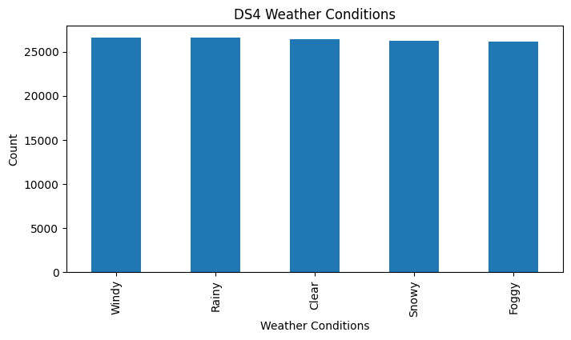

```python
plt.figure(figsize=(8,4))
ds4["Weather Conditions"].value_counts(dropna=False).head(10).plot(kind="bar")
plt.title("DS4 Weather Conditions")
plt.ylabel("Count")
plt.show()
```

We plot the distribution of accident severity levels in DS4 to understand the relative frequency of minor, moderate, and severe accidents. This gives a quick view of the outcome profile of the dataset and helps determine whether severity-based comparisons may be useful in later descriptive analysis.

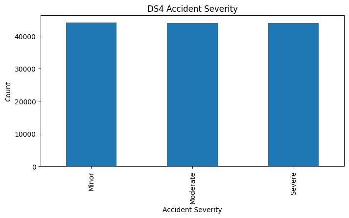

```python
plt.figure(figsize=(8,4))
ds4["Accident Severity"].value_counts(dropna=False).plot(kind="bar")
plt.title("DS4 Accident Severity")
plt.ylabel("Count")
plt.show()
```

We also visualise the distribution of road condition categories in DS4. Road condition is relevant because rainfall may influence accident risk indirectly through changes in surface conditions, traction, and visibility. Exploring this variable gives additional context for interpreting how weather-related factors may relate to accidents.

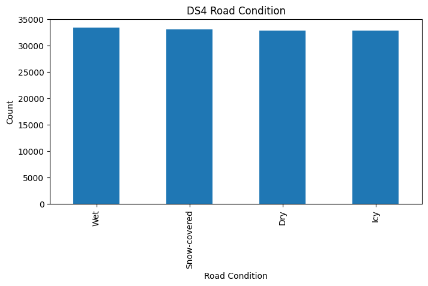

```python
plt.figure(figsize=(8,4))
ds4["Road Condition"].value_counts(dropna=False).head(10).plot(kind="bar")
plt.title("DS4 Road Condition")
plt.ylabel("Count")
plt.show()
```

**Quality considerations for DS4**

We summarize key quality aspects as follows:

- **Value-added is strong**, because DS4 contains rain condition, weather condition, road condition, severity, injuries, and fatalities.
- **Relevancy is moderate**, since DS4 is useful for supporting analysis of rain-related accident outcomes.
- **Completeness appears reasonably strong**, because the notebook exploration did not highlight major missing-value issues.
- **Interpretability is reasonably strong**, because the variables are clearly named and suitable for grouped comparisons.
- **Representational consistency is weak for the main task**, because DS4 does not align naturally with the same location and time structure as the main DS1 + DS2 analysis.
- **Reputation/believability is weaker**, because DS4 is a broad Kaggle “global road accidents” dataset and the available source description does not clearly document the original publisher, collection process, or whether the data is compiled, simulated, or generated.
- **Verifiability is weaker**, since the current metadata is not enough to fully confirm primary-source lineage.

**Conclusion for DS4**

By itself, DS4 is not ideal for directly answering whether higher rainfall corresponds to a higher number of vehicle accidents in the same location. However, it is useful as supporting evidence because it helps examine whether rain-related accidents tend to occur under worse conditions or lead to worse outcomes.

In light of the above data exploration, we consider DS4 suitable for supporting analysis with the following caveats, which we will keep in mind during data preparation and analysis:

- Because DS4 is Kaggle-hosted and its original provenance is not clearly documented in the available metadata, its reliability should be treated more cautiously than that of an official primary source.
- From the available source description, we could not verify whether DS4 is synthetic or compiled from real-world sources, so conclusions drawn from it should be framed as supporting rather than definitive.
- DS4 is not directly aligned with the main rainfall–accident merge, so it should be interpreted as contextual evidence rather than direct proof for the main research question.

#### Overall, DS1 and DS2 are the most important sources for the core rainfall–accident analysis, while DS3 and DS4 contribute additional contextual value but are weaker as direct integration sources due to narrower coverage or lower compatibility with the main analytical pipeline.

## Data Preparation (Process)

### Overview

Our process has one **main pipeline** and two **supporting pipelines**.

The **main pipeline** prepares DS1 and DS2 for direct integration. For **DS1**, we first perform **enriching** by adding station labels to the three rainfall source files, then apply **enriching by union** to combine them into one dataset. We then apply **structuring** to standardize column names and derive consistent time fields. For **DS2**, we apply **structuring** by converting accident dates into a standard format, deriving `Year` and `Month`, and aggregating accident records to monthly accident counts by station.

Before joining the two datasets, we perform **integration profiling** to assess join-key ambiguity, join coverage, and overlap in time periods. We then apply **enriching by inner join** to combine DS1 and DS2 on the shared `(Year, Month, Station)` key. After integration, we perform **profiling of the merged dataset** to verify that the result is clean and analysis-ready.

The **DS3 pipeline** is a supporting context pipeline. We apply **structuring** by retaining only the relevant accident-context variables and standardizing the date field, followed by **profiling** of the prepared dataset. DS3 is then used to support interpretation of the main result.

The **DS4 pipeline** is another supporting context pipeline. We apply **structuring** by selecting the relevant accident-outcome variables, then apply **enriching** by deriving new attributes such as `Rain_Condition` and `Severity_Score`. After that, we perform **profiling** before using DS4 for supporting analysis.

Overall, this pipeline is necessary because the main question cannot be answered from a single dataset. Rainfall, accident counts, and supporting accident-condition evidence come from different sources and must be profiled, structured, enriched, and cleaned before they can be meaningfully analysed together.

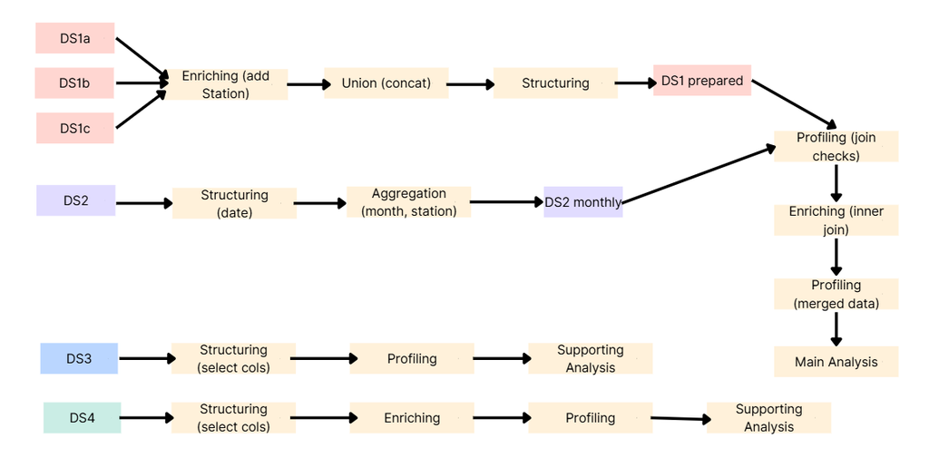

### DS1 Preparation

#### Structuring - Renaming relevant columns

In this step, we will rename the columns in ds1 to improve clarity. Doing so will help increase readability, making the preparation process easier to manage.

```python
ds1_prepared = ds1.rename(columns ={"Value": "Rainfall_inches", "Anomaly": "Rainfall_anomaly"})

display(ds1_prepared.head())
```

|  | Date | Rainfall_inches | Rainfall_anomaly | Station |
| --- | --- | --- | --- | --- |
| 0 | 202001 | 1.93 | -1.62 | CENTRAL PARK |
| 1 | 202002 | 2.55 | -0.61 | CENTRAL PARK |
| 2 | 202003 | 3.78 | -0.55 | CENTRAL PARK |
| 3 | 202004 | 4.50 | 0.50 | CENTRAL PARK |
| 4 | 202005 | 1.65 | -2.43 | CENTRAL PARK |

#### Cleaning - Handling missing values

In this step, we will inspect DS1 for missing values, which may affect grouping, aggregation and feature engineering in the analysis stage. No missing values in DS1, no rows are removed.

```python
# Check missing values
print("Missing values before cleaning:")
display(ds1_prepared.isnull().sum())

# Drop rows where date is missing
ds1_prepared = ds1_prepared.dropna()

print("Missing values after cleaning:")
display(ds1_prepared.isnull().sum())
```

```
Missing values before cleaning:
```

|  | 0 |
| --- | --- |
| Date | 0 |
| Rainfall_inches | 0 |
| Rainfall_anomaly | 0 |
| Station | 0 |

**dtype:** int64

```
Missing values after cleaning:
```

|  | 0 |
| --- | --- |
| Date | 0 |
| Rainfall_inches | 0 |
| Rainfall_anomaly | 0 |
| Station | 0 |

**dtype:** int64

#### Structuring - creating attributes and record-based filtering

We first standardize the Date attribute by converting it into a proper datetime representation. We then apply intrarecord structuring by creating derived temporal attributes, namely Year and Month, from the original date field. These derived attributes make the dataset more analysis-ready by supporting temporal filtering, grouping, and later integration with other datasets.

```python
ds1_prepared["Date"] = pd.to_datetime(ds1_prepared["Date"], format="%Y%m")
ds1_prepared["Year"] = ds1_prepared["Date"].dt.year
ds1_prepared["Month"] = ds1_prepared["Date"].dt.month

display(ds1_prepared)
```

|  | Date | Rainfall_inches | Rainfall_anomaly | Station | Year | Month |
| --- | --- | --- | --- | --- | --- | --- |
| 0 | 2020-01-01 | 1.93 | -1.62 | CENTRAL PARK | 2020 | 1 |
| 1 | 2020-02-01 | 2.55 | -0.61 | CENTRAL PARK | 2020 | 2 |
| 2 | 2020-03-01 | 3.78 | -0.55 | CENTRAL PARK | 2020 | 3 |
| 3 | 2020-04-01 | 4.50 | 0.50 | CENTRAL PARK | 2020 | 4 |
| 4 | 2020-05-01 | 1.65 | -2.43 | CENTRAL PARK | 2020 | 5 |
| ... | ... | ... | ... | ... | ... | ... |
| 211 | 2025-08-01 | 2.21 | -2.59 | LAGUARDIA | 2025 | 8 |
| 212 | 2025-09-01 | 2.76 | -1.96 | LAGUARDIA | 2025 | 9 |
| 213 | 2025-10-01 | 4.09 | -0.04 | LAGUARDIA | 2025 | 10 |
| 214 | 2025-11-01 | 2.09 | -1.11 | LAGUARDIA | 2025 | 11 |
| 215 | 2025-12-01 | 3.39 | -1.14 | LAGUARDIA | 2025 | 12 |

216 rows × 6 columns

We apply record-based filtering to retain only records from 2020 to 2025. This restricts the dataset to the relevant analytical period and ensures that DS1 is aligned with the project scope. Filtering to the target time range also supports better temporal coverage alignment with the accident datasets used later in the analysis.

```python
ds1_prepared = ds1_prepared[(ds1_prepared["Year"] >= 2020) & (ds1_prepared["Year"] <= 2025)]
print(ds1_prepared.shape)  # Should still be 216 rows
```

```
(216, 6)
```

#### Profiling

We perform single-dataset profiling to assess the temporal completeness of DS1. By comparing the observed monthly dates against the full expected monthly date range from January 2020 to December 2025, we identify whether any months are missing from the dataset. This profiling step is important because missing months could affect downstream aggregation, integration, and interpretation of rainfall trends over time.

```python
expected_dates = pd.date_range(start="2020-01", end="2025-12", freq="MS")
missing_months = expected_dates.difference(ds1_prepared["Date"])
if len(missing_months) ==0 :
  print("No missing months")
else:
  print("Missing months:", missing_months)
```

```
No missing months
```

### DS2 Preparation

#### Structuring - Selecting relevant columns

In this step, we retain only the columns in DS2 that are relevant to our research question and later analysis. Since the project focuses on whether rainfall is associated with accident frequency, the most useful fields are the accident date, accident time, and contextual attributes such as crash date, collision_id, borough. Removing unrelated columns helps simplify the dataset, reduces noise, and makes the preparation process easier to manage.

```python
#Select useful columns
ds2_prepared = ds2[["CRASH DATE",
                    "COLLISION_ID",
                    "BOROUGH"
]].copy()

print("DS2 shape after column selection:", ds2_prepared.shape)
display(ds2_prepared.head())
```

```
DS2 shape after column selection: (2237605, 3)
```

|  | CRASH DATE | COLLISION_ID | BOROUGH |
| --- | --- | --- | --- |
| 0 | 2021-09-11 | 4455765 | NaN |
| 1 | 2022-03-26 | 4513547 | NaN |
| 2 | 2023-11-01 | 4675373 | BROOKLYN |
| 3 | 2022-06-29 | 4541903 | NaN |
| 4 | 2022-09-21 | 4566131 | NaN |

#### Cleaning - Handling Mising Values and Irrelevant Boroughs

We inspect DS2 for missing values and unrelated boroughs, which may affect grouping, aggregation and feature engineering in the analysis stage. The relevant boroughs are Queens, Manhattan, Bronx, Brooklyn which is consistent with those in merged ds1

```python
#Drop NA values in BOROUGH
ds2_prepared = ds2_prepared.dropna(subset=["BOROUGH"])

# Keep only the 4 boroughs
valid_boroughs = ["QUEENS", "MANHATTAN", "BRONX", "BROOKLYN"]
ds2_prepared = ds2_prepared[ds2_prepared["BOROUGH"].isin(valid_boroughs)]

print("DS2 shape after column selection:", ds2_prepared.shape)
display(ds2_prepared.head())
```

```
DS2 shape after column selection: (1488829, 3)
```

|  | CRASH DATE | COLLISION_ID | BOROUGH |
| --- | --- | --- | --- |
| 2 | 2023-11-01 | 4675373 | BROOKLYN |
| 9 | 2021-09-11 | 4456314 | BROOKLYN |
| 10 | 2021-12-14 | 4486609 | BROOKLYN |
| 13 | 2021-12-14 | 4486660 | BRONX |
| 14 | 2021-12-14 | 4487074 | BROOKLYN |

#### Structuring - converting to proper format, filtering, renaming

We first convert CRASH DATE into a proper datetime format so that time-based components can be extracted reliably. We then perform intrarecord structuring by creating derived attributes, namely Year and Month, from the crash date. These derived temporal attributes make the dataset more analysis-ready by supporting later grouping, aggregation, and temporal alignment with the rainfall dataset.

```python
ds2_prepared["CRASH DATE"] = pd.to_datetime(ds2_prepared["CRASH DATE"])
ds2_prepared["Year"] = ds2_prepared["CRASH DATE"].dt.year
ds2_prepared["Month"] = ds2_prepared["CRASH DATE"].dt.month

display(ds2_prepared.head())
```

|  | CRASH DATE | COLLISION_ID | BOROUGH | Year | Month |
| --- | --- | --- | --- | --- | --- |
| 2 | 2023-11-01 | 4675373 | BROOKLYN | 2023 | 11 |
| 9 | 2021-09-11 | 4456314 | BROOKLYN | 2021 | 9 |
| 10 | 2021-12-14 | 4486609 | BROOKLYN | 2021 | 12 |
| 13 | 2021-12-14 | 4486660 | BRONX | 2021 | 12 |
| 14 | 2021-12-14 | 4487074 | BROOKLYN | 2021 | 12 |

We apply record-based filtering to retain only accident records from 2021 to 2025. This restricts the dataset to the relevant analytical period and improves temporal coverage alignment with the rainfall dataset. By narrowing the dataset to the overlapping time range, we ensure that subsequent integration and analysis are based on comparable periods.

```python
ds2_prepared = ds2_prepared[(ds2_prepared["Year"] >= 2021) & (ds2_prepared["Year"] <= 2025)]

display(ds2_prepared.head())
```

|  | CRASH DATE | COLLISION_ID | BOROUGH | Year | Month |
| --- | --- | --- | --- | --- | --- |
| 2 | 2023-11-01 | 4675373 | BROOKLYN | 2023 | 11 |
| 9 | 2021-09-11 | 4456314 | BROOKLYN | 2021 | 9 |
| 10 | 2021-12-14 | 4486609 | BROOKLYN | 2021 | 12 |
| 13 | 2021-12-14 | 4486660 | BRONX | 2021 | 12 |
| 14 | 2021-12-14 | 4487074 | BROOKLYN | 2021 | 12 |

We perform intrarecord structuring by creating a derived location attribute, STATION, by mapping each borough to its nearest weather station. This supports later join-based integration with the rainfall dataset, which is indexed by station. After deriving the station attribute, we apply attribute-based filtering by removing the original BOROUGH column since it is no longer needed for integration. Finally, we perform schema refinement through attribute renaming by renaming STATION to Station to improve naming consistency across datasets.

```python
# Step: Map boroughs to their nearest weather station
borough_to_station = {
    "MANHATTAN": "CENTRAL PARK",
    "BRONX": "CENTRAL PARK",
    "QUEENS": "LAGUARDIA",
    "BROOKLYN": "JFK"
}

# Only perform mapping if 'BOROUGH' column still exists
if "BOROUGH" in ds2_prepared.columns:
    ds2_prepared["STATION"] = ds2_prepared["BOROUGH"].map(borough_to_station)
    # Drop "Borough" Column after mapping
    ds2_prepared.drop(columns=["BOROUGH"], inplace=True)
else:
    print("Warning: 'BOROUGH' column not found in ds2_prepared. Assuming mapping was already done or column was removed upstream.")

ds2_prepared.rename(columns={"STATION": "Station"}, inplace=True)
display(ds2_prepared)
```

|  | CRASH DATE | COLLISION_ID | Year | Month | Station |
| --- | --- | --- | --- | --- | --- |
| 2 | 2023-11-01 | 4675373 | 2023 | 11 | JFK |
| 9 | 2021-09-11 | 4456314 | 2021 | 9 | JFK |
| 10 | 2021-12-14 | 4486609 | 2021 | 12 | JFK |
| 13 | 2021-12-14 | 4486660 | 2021 | 12 | CENTRAL PARK |
| 14 | 2021-12-14 | 4487074 | 2021 | 12 | JFK |
| ... | ... | ... | ... | ... | ... |
| 2236933 | 2025-12-28 | 4873938 | 2025 | 12 | CENTRAL PARK |
| 2237249 | 2025-01-15 | 4873909 | 2025 | 1 | CENTRAL PARK |
| 2237440 | 2025-11-22 | 4874393 | 2025 | 11 | LAGUARDIA |
| 2237468 | 2025-01-27 | 4874320 | 2025 | 1 | JFK |
| 2237483 | 2025-12-21 | 4874362 | 2025 | 12 | LAGUARDIA |

326841 rows × 5 columns

#### Aggregate to monthly accident count per station

```python
ds2_monthly = ds2_prepared.groupby(["Year", "Month", "Station"]).agg(
    total_accidents=("COLLISION_ID", "count")
).reset_index()

display(ds2_monthly)
```

|  | Year | Month | Station | total_accidents |
| --- | --- | --- | --- | --- |
| 0 | 2021 | 1 | CENTRAL PARK | 1616 |
| 1 | 2021 | 1 | JFK | 1806 |
| 2 | 2021 | 1 | LAGUARDIA | 1404 |
| 3 | 2021 | 2 | CENTRAL PARK | 1432 |
| 4 | 2021 | 2 | JFK | 1635 |
| ... | ... | ... | ... | ... |
| 175 | 2025 | 11 | JFK | 2042 |
| 176 | 2025 | 11 | LAGUARDIA | 1517 |
| 177 | 2025 | 12 | CENTRAL PARK | 1991 |
| 178 | 2025 | 12 | JFK | 2086 |
| 179 | 2025 | 12 | LAGUARDIA | 1587 |

180 rows × 4 columns

### DS3 Preparation

#### Structuring - Selecting relevant columns

In this step, we retain only the columns in DS3 that are relevant to our research question and later analysis. Since the project focuses on whether rainfall is associated with accident frequency, the most useful fields are the accident date, accident time, and contextual attributes such as weather, road surface, lighting condition, and road class. Removing unrelated columns helps simplify the dataset, reduces noise, and makes the preparation process easier to manage.

```python
# Select useful columns
ds3_prepared = ds3[[
    "Accident Date",
    "Time (24hr)",
    "Weather Conditions",
    "Road Surface",
    "Lighting Conditions",
    "1st Road Class"
]].copy()

print("DS3 shape after column selection:", ds3_prepared.shape)
display(ds3_prepared.head())
```

```
DS3 shape after column selection: (314, 6)
```

|  | Accident Date | Time (24hr) | Weather Conditions | Road Surface | Lighting Conditions | 1st Road Class |
| --- | --- | --- | --- | --- | --- | --- |
| 0 | 2018-01-03 | 2054 | Raining without high winds | Wet / Damp | Darkness: street lights present and lit | Unclassified |
| 1 | 2018-01-04 | 551 | Raining without high winds | Wet / Damp | Darkness: street lights present and lit | A |
| 2 | 2018-01-05 | 1650 | Fine without high winds | Wet / Damp | Darkness: street lights present and lit | Unclassified |
| 3 | 2018-01-10 | 744 | Fine without high winds | Wet / Damp | Daylight: street lights present | A |
| 4 | 2018-01-14 | 348 | Fine without high winds | Wet / Damp | Darkness: street lighting unknown | Motorway |

#### Cleaning - Handling missing values

We inspect DS3 for missing values, which may affect grouping, aggregation and feature engineering in the analysis stage. No missing values were detected, so no rows were removed

```python
# Check missing values
print("Missing values before cleaning:")
display(ds3_prepared.isnull().sum())

# Drop rows where date is missing
ds3_prepared = ds3_prepared.dropna(subset=["Accident Date"])

# Fill categorical missing values
categorical_cols = [
    "Weather Conditions",
    "Road Surface",
    "Lighting Conditions",
    "1st Road Class"
]

for col in categorical_cols:
    ds3_prepared[col] = ds3_prepared[col].fillna("Unknown")

print("Missing values after cleaning:")
display(ds3_prepared.isnull().sum())
```

```
Missing values before cleaning:
```

|  | 0 |
| --- | --- |
| Accident Date | 0 |
| Time (24hr) | 0 |
| Weather Conditions | 0 |
| Road Surface | 0 |
| Lighting Conditions | 0 |
| 1st Road Class | 0 |

**dtype:** int64

```
Missing values after cleaning:
```

|  | 0 |
| --- | --- |
| Accident Date | 0 |
| Time (24hr) | 0 |
| Weather Conditions | 0 |
| Road Surface | 0 |
| Lighting Conditions | 0 |
| 1st Road Class | 0 |

**dtype:** int64

#### Structuring - Creating attributes

```python
# Extract date features
ds3_prepared["Year"] = ds3_prepared["Accident Date"].dt.year
ds3_prepared["Month"] = ds3_prepared["Accident Date"].dt.month
ds3_prepared["Day"] = ds3_prepared["Accident Date"].dt.day
ds3_prepared["Weekday"] = ds3_prepared["Accident Date"].dt.day_name()

# Convert time column
ds3_prepared["Hour"] = pd.to_numeric(
    ds3_prepared["Time (24hr)"],
    errors="coerce"
)

print("Feature engineered dataset:")
display(ds3_prepared.head())
```

```
Feature engineered dataset:
```

|  | Accident Date | Time (24hr) | Weather Conditions | Road Surface | Lighting Conditions | 1st Road Class | Year | Month | Day | Weekday | Hour |
| --- | --- | --- | --- | --- | --- | --- | --- | --- | --- | --- | --- |
| 0 | 2018-01-03 | 2054 | Raining without high winds | Wet / Damp | Darkness: street lights present and lit | Unclassified | 2018 | 1 | 3 | Wednesday | 2054 |
| 1 | 2018-01-04 | 551 | Raining without high winds | Wet / Damp | Darkness: street lights present and lit | A | 2018 | 1 | 4 | Thursday | 551 |
| 2 | 2018-01-05 | 1650 | Fine without high winds | Wet / Damp | Darkness: street lights present and lit | Unclassified | 2018 | 1 | 5 | Friday | 1650 |
| 3 | 2018-01-10 | 744 | Fine without high winds | Wet / Damp | Daylight: street lights present | A | 2018 | 1 | 10 | Wednesday | 744 |
| 4 | 2018-01-14 | 348 | Fine without high winds | Wet / Damp | Darkness: street lighting unknown | Motorway | 2018 | 1 | 14 | Sunday | 348 |

Since the research question is about the relationship between rainfall and accidents, it is useful to derive a rain-related indicator from the weather condition field. In this step, we create a new binary variable called Rain_Condition. Records containing weather descriptions such as rain, snow, or sleet are labelled as 1, while all other conditions are labelled as 0. This simplifies the weather information into a form that can be more easily analysed and compared against accident frequency.

```python
# Create rain indicator from weather conditions
rain_keywords = ["rain", "snow", "sleet"]

ds3_prepared["Rain_Condition"] = ds3_prepared["Weather Conditions"].str.lower().apply(
    lambda x: 1 if any(word in str(x) for word in rain_keywords) else 0
)

print("Rain condition distribution:")
display(ds3_prepared["Rain_Condition"].value_counts())
```

```
Rain condition distribution:
```

| Rain_Condition | count |
| --- | --- |
| 0 | 267 |
| 1 | 47 |

**dtype:** int64

#### Aggregating accident counts by month

Because DS1 records rainfall at the monthly level, DS3 should also be aggregated to the same time granularity for meaningful comparison. In this step, we group the accident records by year and month, then count the number of accidents in each month. This produces a monthly accident summary that can later be merged with DS1 rainfall values for correlation analysis and visualisation.

```python
# Monthly accident counts
ds3_monthly = ds3_prepared.groupby(["Year", "Month"]).size().reset_index(name="Accident_Count")

print("Monthly accident counts:")
display(ds3_monthly.head())
```

```
Monthly accident counts:
```

|  | Year | Month | Accident_Count |
| --- | --- | --- | --- |
| 0 | 2018 | 1 | 26 |
| 1 | 2018 | 2 | 18 |
| 2 | 2018 | 3 | 30 |
| 3 | 2018 | 4 | 22 |
| 4 | 2018 | 5 | 23 |

### DS4 Preparation

#### Structuring - Selecting relevant columns

For DS4, we first retain the variables that are most useful for accident context analysis. These include the year and month of the accident, weather and road conditions, accident severity, region, and numeric measures such as the number of vehicles involved, injuries, and fatalities. Selecting only the relevant columns keeps the dataset focused and avoids unnecessary complexity during cleaning and feature engineering.

```python
ds4_prepared = ds4[[
    "Year",
    "Month",
    "Weather Conditions",
    "Road Condition",
    "Accident Severity",
    "Number of Vehicles Involved",
    "Number of Injuries",
    "Number of Fatalities",
    "Region"
]].copy()

print("DS4 shape after column selection:", ds4_prepared.shape)
display(ds4_prepared.head())
```

```
DS4 shape after column selection: (132000, 9)
```

|  | Year | Month | Weather Conditions | Road Condition | Accident Severity | Number of Vehicles Involved | Number of Injuries | Number of Fatalities | Region |
| --- | --- | --- | --- | --- | --- | --- | --- | --- | --- |
| 0 | 2002 | October | Windy | Wet | Moderate | 1 | 8 | 2 | Europe |
| 1 | 2014 | December | Windy | Snow-covered | Minor | 3 | 6 | 1 | North America |
| 2 | 2012 | July | Snowy | Wet | Moderate | 4 | 13 | 4 | South America |
| 3 | 2017 | May | Clear | Icy | Minor | 2 | 6 | 3 | Australia |
| 4 | 2002 | July | Rainy | Icy | Moderate | 1 | 13 | 4 | South America |

#### Cleaning - Handling missing values

Next, we inspect DS4 for missing values and handle them appropriately. For categorical variables such as weather conditions, road condition, accident severity, and region, missing entries are replaced with "Unknown" so that the rows can still be preserved. For numeric variables such as number of vehicles involved, injuries, and fatalities, missing values are filled using the median of each column. The median is used because it is less affected by extreme values than the mean and is often more suitable for accident-related data.

```python
print("Missing values before cleaning:")
display(ds4_prepared.isnull().sum())

# Fill categorical columns
categorical_cols = [
    "Weather Conditions",
    "Road Condition",
    "Accident Severity",
    "Region"
]

for col in categorical_cols:
    ds4_prepared[col] = ds4_prepared[col].fillna("Unknown")

# Fill numeric columns with median
numeric_cols = [
    "Number of Vehicles Involved",
    "Number of Injuries",
    "Number of Fatalities"
]

for col in numeric_cols:
    ds4_prepared[col] = ds4_prepared[col].fillna(ds4_prepared[col].median())

print("Missing values after cleaning:")
display(ds4_prepared.isnull().sum())
```

```
Missing values before cleaning:
```

|  | 0 |
| --- | --- |
| Year | 0 |
| Month | 0 |
| Weather Conditions | 0 |
| Road Condition | 0 |
| Accident Severity | 0 |
| Number of Vehicles Involved | 0 |
| Number of Injuries | 0 |
| Number of Fatalities | 0 |
| Region | 0 |

**dtype:** int64

```
Missing values after cleaning:
```

|  | 0 |
| --- | --- |
| Year | 0 |
| Month | 0 |
| Weather Conditions | 0 |
| Road Condition | 0 |
| Accident Severity | 0 |
| Number of Vehicles Involved | 0 |
| Number of Injuries | 0 |
| Number of Fatalities | 0 |
| Region | 0 |

**dtype:** int64

#### Structuring - Creating attributes

To make DS4 more relevant to the research question, we again derive a rain-related indicator from the weather condition column. This binary feature labels accidents that occurred under rainy conditions as 1, and non-rainy conditions as 0. Creating this variable allows us to compare accident severity and outcomes under rainy versus non-rainy contexts more easily

```python
ds4_prepared["Rain_Condition"] = ds4_prepared["Weather Conditions"].str.lower().apply(
    lambda x: 1 if "rain" in str(x) else 0
)

display(ds4_prepared["Rain_Condition"].value_counts())
```

| Rain_Condition | count |
| --- | --- |
| 0 | 105438 |
| 1 | 26562 |

**dtype:** int64

Accident severity is usually recorded as a categorical variable, but numeric values are often more convenient for summarisation and analysis. In this step, we map each severity category to a numerical score. For example, minor accidents are assigned a lower score, while fatal accidents are assigned a higher score. This does not replace the original severity column, but provides an additional feature that can be averaged or compared across months and weather conditions.

```python
severity_map = {
    "Minor": 1,
    "Moderate": 2,
    "Serious": 3,
    "Severe": 4,
    "Fatal": 5
}

ds4_prepared["Severity_Score"] = ds4_prepared["Accident Severity"].map(severity_map)

display(ds4_prepared.head())
```

|  | Year | Month | Weather Conditions | Road Condition | Accident Severity | Number of Vehicles Involved | Number of Injuries | Number of Fatalities | Region | Rain_Condition | Severity_Score |
| --- | --- | --- | --- | --- | --- | --- | --- | --- | --- | --- | --- |
| 0 | 2002 | October | Windy | Wet | Moderate | 1 | 8 | 2 | Europe | 0 | 2 |
| 1 | 2014 | December | Windy | Snow-covered | Minor | 3 | 6 | 1 | North America | 0 | 1 |
| 2 | 2012 | July | Snowy | Wet | Moderate | 4 | 13 | 4 | South America | 0 | 2 |
| 3 | 2017 | May | Clear | Icy | Minor | 2 | 6 | 3 | Australia | 0 | 1 |
| 4 | 2002 | July | Rainy | Icy | Moderate | 1 | 13 | 4 | South America | 1 | 2 |

#### Aggregating DS4 by month

Finally, we aggregate DS4 at the monthly level so that it becomes easier to compare with DS1 rainfall data and with the monthly accident summaries from DS3. In this step, we group the data by year and month, then compute total injuries, total fatalities, and the average severity score for each month. This creates a compact summary of accident outcomes over time, which can later be used for descriptive analysis and visualisation.

```python
ds4_monthly = ds4_prepared.groupby(["Year", "Month"]).agg({
    "Weather Conditions": lambda x: x.mode().iloc[0] if not x.mode().empty else None,
    "Road Condition": lambda x: x.mode().iloc[0] if not x.mode().empty else None,
    "Number of Injuries": "sum",
    "Number of Fatalities": "sum",
    "Severity_Score": "mean"
}).reset_index()

print("DS4 aggregated dataset:")
display(ds4_monthly.head())
```

```
DS4 aggregated dataset:
```

|  | Year | Month | Weather Conditions | Road Condition | Number of Injuries | Number of Fatalities | Severity_Score |
| --- | --- | --- | --- | --- | --- | --- | --- |
| 0 | 2000 | April | Foggy | Wet | 3853 | 781 | 2.269880 |
| 1 | 2000 | August | Windy | Snow-covered | 4459 | 891 | 2.412556 |
| 2 | 2000 | December | Clear | Wet | 3895 | 870 | 2.325472 |
| 3 | 2000 | February | Windy | Dry | 4193 | 876 | 2.191142 |
| 4 | 2000 | January | Rainy | Dry | 4322 | 895 | 2.286957 |

### Integration profiling before enriching (merge)

Before merging DS1 and DS2, we perform additional profiling on the integration step itself. Earlier profiling focused on each dataset individually by checking shape, columns, data types, missing values, duplicates, and summary statistics. However, because our main analysis depends on combining datasets from different sources, we also need to assess whether the join is reliable and how much data will actually be retained after integration.

Specifically, we check three things. First, we test whether the join key is ambiguous by checking if the same `(Year, Month, Station)` combination appears more than once in either dataset. This matters because duplicate join keys can duplicate rows in the merged output. Second, we perform join coverage analysis by comparing the distinct keys in DS1 and DS2 to see how many records match across both datasets and how many appear only in one source. Third, we compare the time-period coverage of both datasets to make explicit what data is lost when we use an inner join.

These checks strengthen the profiling stage because they move beyond single-dataset summaries and evaluate the quality of the integration itself before the merge is carried out.

```python
# Integration profiling before merge

# Create comparable join-key views
ds1_keys = ds1_prepared[["Year", "Month", "Station"]].copy()
ds2_keys = ds2_monthly[["Year", "Month", "Station"]]

# Standardize station names for safer matching
ds1_keys["Station"] = ds1_keys["Station"].astype(str).str.strip().str.upper()
ds2_keys["Station"] = ds2_keys["Station"].astype(str).str.strip().str.upper()

print("=== 1. Join key ambiguity check ===")
ds1_dup = ds1_keys.duplicated(subset=["Year", "Month", "Station"]).sum()
ds2_dup = ds2_keys.duplicated(subset=["Year", "Month", "Station"]).sum()

print(f"Duplicate join keys in DS1: {ds1_dup}")
print(f"Duplicate join keys in DS2: {ds2_dup}")

if ds1_dup > 0:
    print("\nSample duplicated keys in DS1:")
    display(
        ds1_keys[ds1_keys.duplicated(subset=["Year", "Month", "Station"], keep=False)]
        .value_counts(["Year", "Month", "Station"])
        .reset_index(name="count")
        .head(10)
    )

if ds2_dup > 0:
    print("\nSample duplicated keys in DS2:")
    display(
        ds2_keys[ds2_keys.duplicated(subset=["Year", "Month", "Station"], keep=False)]
        .value_counts(["Year", "Month", "Station"])
        .reset_index(name="count")
        .head(10)
    )

print("\n=== 2. Join coverage analysis ===")
ds1_unique = ds1_keys.drop_duplicates()
ds2_unique = ds2_keys.drop_duplicates()

coverage = ds1_unique.merge(
    ds2_unique,
    on=["Year", "Month", "Station"],
    how="outer",
    indicator=True
)

coverage_summary = (
    coverage["_merge"]
    .value_counts()
    .rename_axis("coverage_status")
    .reset_index(name="count")
)
coverage_summary["percentage"] = (coverage_summary["count"] / len(coverage) * 100).round(2)

display(coverage_summary)

print("\nSample keys only in DS1:")
display(coverage[coverage["_merge"] == "left_only"].head(10))

print("\nSample keys only in DS2:")
display(coverage[coverage["_merge"] == "right_only"].head(10))

print("\n=== 3. Time-period overlap analysis ===")
ds1_periods = ds1_unique[["Year", "Month"]].drop_duplicates().copy()
ds2_periods = ds2_unique[["Year", "Month"]].drop_duplicates().copy()

ds1_periods["period"] = pd.to_datetime(dict(year=ds1_periods["Year"], month=ds1_periods["Month"], day=1))
ds2_periods["period"] = pd.to_datetime(dict(year=ds2_periods["Year"], month=ds2_periods["Month"], day=1))

print("DS1 period range:", ds1_periods["period"].min().date(), "to", ds1_periods["period"].max().date())
print("DS2 period range:", ds2_periods["period"].min().date(), "to", ds2_periods["period"].max().date())

period_overlap = ds1_periods[["period"]].merge(
    ds2_periods[["period"]],
    on="period",
    how="outer",
    indicator=True
)

period_summary = (
    period_overlap["_merge"]
    .value_counts()
    .rename_axis("period_status")
    .reset_index(name="count")
)

display(period_summary)

print("\nMonths only in DS1:")
display(period_overlap[period_overlap["_merge"] == "left_only"].head(12))

print("\nMonths only in DS2:")
display(period_overlap[period_overlap["_merge"] == "right_only"].head(12))
```

```
=== 1. Join key ambiguity check ===
Duplicate join keys in DS1: 0
Duplicate join keys in DS2: 0

=== 2. Join coverage analysis ===
```

|  | coverage_status | count | percentage |
| --- | --- | --- | --- |
| 0 | both | 180 | 83.33 |
| 1 | left_only | 36 | 16.67 |
| 2 | right_only | 0 | 0.00 |

```
Sample keys only in DS1:
```

|  | Year | Month | Station | _merge |
| --- | --- | --- | --- | --- |
| 0 | 2020 | 1 | CENTRAL PARK | left_only |
| 1 | 2020 | 1 | JFK | left_only |
| 2 | 2020 | 1 | LAGUARDIA | left_only |
| 3 | 2020 | 2 | CENTRAL PARK | left_only |
| 4 | 2020 | 2 | JFK | left_only |
| 5 | 2020 | 2 | LAGUARDIA | left_only |
| 6 | 2020 | 3 | CENTRAL PARK | left_only |
| 7 | 2020 | 3 | JFK | left_only |
| 8 | 2020 | 3 | LAGUARDIA | left_only |
| 9 | 2020 | 4 | CENTRAL PARK | left_only |

```
Sample keys only in DS2:
```

|  | Year | Month | Station | _merge |
| --- | --- | --- | --- | --- |

```
=== 3. Time-period overlap analysis ===
DS1 period range: 2020-01-01 to 2025-12-01
DS2 period range: 2021-01-01 to 2025-12-01
```

|  | period_status | count |
| --- | --- | --- |
| 0 | both | 60 |
| 1 | left_only | 12 |
| 2 | right_only | 0 |

```
Months only in DS1:
```

|  | period | _merge |
| --- | --- | --- |
| 0 | 2020-01-01 | left_only |
| 1 | 2020-02-01 | left_only |
| 2 | 2020-03-01 | left_only |
| 3 | 2020-04-01 | left_only |
| 4 | 2020-05-01 | left_only |
| 5 | 2020-06-01 | left_only |
| 6 | 2020-07-01 | left_only |
| 7 | 2020-08-01 | left_only |
| 8 | 2020-09-01 | left_only |
| 9 | 2020-10-01 | left_only |
| 10 | 2020-11-01 | left_only |
| 11 | 2020-12-01 | left_only |

```
Months only in DS2:
```

|  | period | _merge |
| --- | --- | --- |

Integration profiling results

The integration profiling shows that the join key `(Year, Month, Station)` is not ambiguous, since no duplicate key combinations were found in either DS1 or DS2. This means the merge is well defined and is not expected to create duplicated rows due to repeated join keys.

The join coverage analysis shows that **180 keys match across both datasets**, while **36 keys appear only in DS1** and **0 keys appear only in DS2**. This indicates that all DS2 records in the shared time period have corresponding matches in DS1. The unmatched DS1 records are expected, since they correspond to time periods that are not covered by DS2.

The time-period overlap analysis confirms this interpretation. DS1 covers **2020-01 to 2025-12**, whereas DS2 covers **2021-01 to 2025-12**. Therefore, the **12 months in 2020** are present only in DS1 and will be excluded by the inner join. Since DS1 contains three stations, this results in **36 left-only keys** in total.

Overall, the profiling indicates that the integration between DS1 and DS2 is reliable after standardizing the station names. The only data lost in the inner join is the DS1 data from 2020, which is expected because DS2 does not contain records for that year.

### Enriching DS1 and DS2 by Inner Join

In this step, we apply **enriching by inner join** to combine DS1 and DS2 on the shared `(Year, Month, Station)` key. This integration adds accident-count information to the rainfall data so that both variables can be analysed together in one table. We use an inner join because the main analysis should only retain records that are present in both datasets over the shared time period and location key.

```python
merged = pd.merge(ds1_prepared, ds2_monthly,
                  left_on=["Year", "Month", "Station"],
                  right_on=["Year", "Month", "Station"],
                  how="inner")

display(merged)
```

|  | Date | Rainfall_inches | Rainfall_anomaly | Station | Year | Month | total_accidents |
| --- | --- | --- | --- | --- | --- | --- | --- |
| 0 | 2021-01-01 | 2.31 | -1.24 | CENTRAL PARK | 2021 | 1 | 1616 |
| 1 | 2021-02-01 | 5.13 | 1.97 | CENTRAL PARK | 2021 | 2 | 1432 |
| 2 | 2021-03-01 | 3.41 | -0.92 | CENTRAL PARK | 2021 | 3 | 1824 |
| 3 | 2021-04-01 | 2.70 | -1.30 | CENTRAL PARK | 2021 | 4 | 1896 |
| 4 | 2021-05-01 | 4.36 | 0.28 | CENTRAL PARK | 2021 | 5 | 2297 |
| ... | ... | ... | ... | ... | ... | ... | ... |
| 175 | 2025-08-01 | 2.21 | -2.59 | LAGUARDIA | 2025 | 8 | 1456 |
| 176 | 2025-09-01 | 2.76 | -1.96 | LAGUARDIA | 2025 | 9 | 1574 |
| 177 | 2025-10-01 | 4.09 | -0.04 | LAGUARDIA | 2025 | 10 | 1551 |
| 178 | 2025-11-01 | 2.09 | -1.11 | LAGUARDIA | 2025 | 11 | 1517 |
| 179 | 2025-12-01 | 3.39 | -1.14 | LAGUARDIA | 2025 | 12 | 1587 |

180 rows × 7 columns

### Profiling of the Merged Dataset

```python
# -----------------------------------
# Re-profile merged dataset
# -----------------------------------

print("=== 1. Basic merged dataset profile ===")
print("Merged shape:", merged.shape)
display(merged.head())

print("\n=== 2. Data types ===")
display(merged.dtypes.to_frame("dtype"))

print("\n=== 3. Missing values per column ===")
missing_counts = merged.isnull().sum().sort_values(ascending=False)
missing_pct = (merged.isnull().mean() * 100).sort_values(ascending=False).round(2)

missing_profile = pd.DataFrame({
    "missing_count": missing_counts,
    "missing_percentage": missing_pct
})
display(missing_profile)

print("\n=== 4. Duplicate join-key check in merged dataset ===")
merged_dup_keys = merged.duplicated(subset=["Year", "Month", "Station"]).sum()
print("Duplicate (Year, Month, Station) keys in merged data:", merged_dup_keys)

if merged_dup_keys > 0:
    print("\nSample duplicated merged keys:")
    display(
        merged[merged.duplicated(subset=["Year", "Month", "Station"], keep=False)]
        .value_counts(["Year", "Month", "Station"])
        .reset_index(name="count")
        .head(10)
    )

print("\n=== 5. Station coverage ===")
print("Unique stations in merged dataset:", merged["Station"].nunique())
print("Stations:", sorted(merged["Station"].dropna().unique()))

station_counts = merged["Station"].value_counts().reset_index()
station_counts.columns = ["Station", "record_count"]
display(station_counts)

print("\n=== 6. Time-period coverage ===")
merged_periods = merged[["Year", "Month"]].drop_duplicates().copy()
merged_periods["period"] = pd.to_datetime(
    dict(year=merged_periods["Year"], month=merged_periods["Month"], day=1)
)

print("Merged period range:", merged_periods["period"].min().date(), "to", merged_periods["period"].max().date())
print("Number of distinct months in merged data:", merged_periods["period"].nunique())

print("\nSample merged periods:")
display(merged_periods.sort_values("period").head(12))

print("\n=== 7. Summary statistics ===")
display(merged.describe(include="all"))

# Optional: focus on key numeric columns if you want a cleaner view
candidate_numeric_cols = [col for col in ["Rainfall_inches", "Rainfall_anomaly", "Accident_Count"] if col in merged.columns]

if candidate_numeric_cols:
    print("\n=== 8. Summary statistics for key numeric columns ===")
    display(merged[candidate_numeric_cols].describe())
```

```
=== 1. Basic merged dataset profile ===
Merged shape: (180, 7)
```

|  | Date | Rainfall_inches | Rainfall_anomaly | Station | Year | Month | total_accidents |
| --- | --- | --- | --- | --- | --- | --- | --- |
| 0 | 2021-01-01 | 2.31 | -1.24 | CENTRAL PARK | 2021 | 1 | 1616 |
| 1 | 2021-02-01 | 5.13 | 1.97 | CENTRAL PARK | 2021 | 2 | 1432 |
| 2 | 2021-03-01 | 3.41 | -0.92 | CENTRAL PARK | 2021 | 3 | 1824 |
| 3 | 2021-04-01 | 2.70 | -1.30 | CENTRAL PARK | 2021 | 4 | 1896 |
| 4 | 2021-05-01 | 4.36 | 0.28 | CENTRAL PARK | 2021 | 5 | 2297 |

```
=== 2. Data types ===
```

|  | dtype |
| --- | --- |
| Date | datetime64[ns] |
| Rainfall_inches | float64 |
| Rainfall_anomaly | float64 |
| Station | object |
| Year | int32 |
| Month | int32 |
| total_accidents | int64 |

```
=== 3. Missing values per column ===
```

|  | missing_count | missing_percentage |
| --- | --- | --- |
| Date | 0 | 0.0 |
| Rainfall_inches | 0 | 0.0 |
| Rainfall_anomaly | 0 | 0.0 |
| Station | 0 | 0.0 |
| Year | 0 | 0.0 |
| Month | 0 | 0.0 |
| total_accidents | 0 | 0.0 |

```
=== 4. Duplicate join-key check in merged dataset ===
Duplicate (Year, Month, Station) keys in merged data: 0

=== 5. Station coverage ===
Unique stations in merged dataset: 3
Stations: ['CENTRAL PARK', 'JFK', 'LAGUARDIA']
```

|  | Station | record_count |
| --- | --- | --- |
| 0 | CENTRAL PARK | 60 |
| 1 | JFK | 60 |
| 2 | LAGUARDIA | 60 |

```
=== 6. Time-period coverage ===
Merged period range: 2021-01-01 to 2025-12-01
Number of distinct months in merged data: 60

Sample merged periods:
```

|  | Year | Month | period |
| --- | --- | --- | --- |
| 0 | 2021 | 1 | 2021-01-01 |
| 1 | 2021 | 2 | 2021-02-01 |
| 2 | 2021 | 3 | 2021-03-01 |
| 3 | 2021 | 4 | 2021-04-01 |
| 4 | 2021 | 5 | 2021-05-01 |
| 5 | 2021 | 6 | 2021-06-01 |
| 6 | 2021 | 7 | 2021-07-01 |
| 7 | 2021 | 8 | 2021-08-01 |
| 8 | 2021 | 9 | 2021-09-01 |
| 9 | 2021 | 10 | 2021-10-01 |
| 10 | 2021 | 11 | 2021-11-01 |
| 11 | 2021 | 12 | 2021-12-01 |

```
=== 7. Summary statistics ===
```

|  | Date | Rainfall_inches | Rainfall_anomaly | Station | Year | Month | total_accidents |
| --- | --- | --- | --- | --- | --- | --- | --- |
| count | 180 | 180.000000 | 180.000000 | 180 | 180.000000 | 180.000000 | 180.000000 |
| unique | NaN | NaN | NaN | 3 | NaN | NaN | NaN |
| top | NaN | NaN | NaN | CENTRAL PARK | NaN | NaN | NaN |
| freq | NaN | NaN | NaN | 60 | NaN | NaN | NaN |
| mean | 2023-06-16 20:48:00 | 4.189333 | 0.071833 | NaN | 2023.000000 | 6.500000 | 1815.783333 |
| min | 2021-01-01 00:00:00 | 0.010000 | -4.120000 | NaN | 2021.000000 | 1.000000 | 1265.000000 |
| 25% | 2022-03-24 06:00:00 | 2.442500 | -1.315000 | NaN | 2022.000000 | 3.750000 | 1575.500000 |
| 50% | 2023-06-16 00:00:00 | 3.690000 | -0.345000 | NaN | 2023.000000 | 6.500000 | 1830.000000 |
| 75% | 2024-09-08 12:00:00 | 5.162500 | 0.995000 | NaN | 2024.000000 | 9.250000 | 2027.000000 |
| max | 2025-12-01 00:00:00 | 14.250000 | 9.530000 | NaN | 2025.000000 | 12.000000 | 2457.000000 |
| std | NaN | 2.666533 | 2.435150 | NaN | 1.418158 | 3.461682 | 275.426967 |

```
=== 8. Summary statistics for key numeric columns ===
```

|  | Rainfall_inches | Rainfall_anomaly |
| --- | --- | --- |
| count | 180.000000 | 180.000000 |
| mean | 4.189333 | 0.071833 |
| std | 2.666533 | 2.435150 |
| min | 0.010000 | -4.120000 |
| 25% | 2.442500 | -1.315000 |
| 50% | 3.690000 | -0.345000 |
| 75% | 5.162500 | 0.995000 |
| max | 14.250000 | 9.530000 |

The data type profile shows that the variables are stored in appropriate formats for downstream analysis. In particular, `Date` is stored as a datetime field, rainfall-related attributes are numeric (`float64`), `Year` and `Month` are stored as integers, and `total_accidents` is stored as an integer count. This suggests that the merged dataset is structurally suitable for time-based analysis and correlation analysis.

The missing-value profile shows that **all columns have 0 missing values (0.0%)**. This means that the merge did not introduce null values into the integrated dataset, and no additional cleaning is required at this stage for missing data.

The duplicate-key check also shows that there are **0 duplicated `(Year, Month, Station)` combinations** in the merged dataset. This confirms that the join key remains unique after integration and that each record in the merged table represents exactly one station-month combination.

The station coverage profile shows that the merged dataset contains **3 unique stations**: **Central Park, JFK, and LaGuardia**. Each station contributes **60 records**, which indicates balanced coverage across stations in the final dataset.

The time-period profile shows that the merged dataset spans **2021-01-01 to 2025-12-01**, covering **60 distinct months**. This is consistent with the earlier integration profiling, which showed that only the overlapping period between DS1 and DS2 is retained after the inner join.

Finally, the summary statistics indicate that the rainfall and accident variables remain interpretable after merging. For example, `Rainfall_inches` ranges from **0.01** to **14.25**, while `total_accidents` ranges from **1265** to **2457**. Overall, the re-profiling confirms that the merged dataset is clean, complete, structurally consistent, and suitable for the subsequent analysis stage.

## Data Analysis (Analyse)

This project mainly conducts diagnostic analysis, because the goal is to understand whether rainfall is associated with accident occurrence and accident-related conditions rather than to forecast future accidents.

The analysis methods used are:

- time-based trend visualization of rainfall and accident counts,
- correlation analysis,
- grouped comparison between lower-rainfall and higher-rainfall periods,
- hypothesis testing for group differences, and
- supporting contextual analysis on weather condition, road surface condition, and accident severity using DS3 and DS4.

### DS1 + DS2 Analysis

We first create one monthly analysis table from the merged DS1 + DS2 dataset. This gives one row per month, which is needed for time-based visualization, correlation analysis, and hypothesis testing.

```python
import pandas as pd
import matplotlib.pyplot as plt
import seaborn as sns

from scipy.stats import pearsonr, spearmanr, ttest_ind, chi2_contingency

# --- DS1 + DS2 monthly analysis table ---
analysis_base = merged.copy()
analysis_base["Date"] = pd.to_datetime(analysis_base["Date"])
analysis_base = analysis_base.sort_values(["Date", "Station"]).reset_index(drop=True)

# Check if accident count is identical across stations within each month
accident_uniqueness = (
    analysis_base.groupby("Date")["total_accidents"]
    .nunique()
    .reset_index(name="n_unique_accident_values")
)

if accident_uniqueness["n_unique_accident_values"].max() == 1:
    monthly_analysis = (
        analysis_base.groupby("Date")
        .agg(
            Rainfall_inches=("Rainfall_inches", "mean"),
            Rainfall_anomaly=("Rainfall_anomaly", "mean"),
            total_accidents=("total_accidents", "first")
        )
        .reset_index()
    )
else:
    monthly_analysis = (
        analysis_base.groupby("Date")
        .agg(
            Rainfall_inches=("Rainfall_inches", "mean"),
            Rainfall_anomaly=("Rainfall_anomaly", "mean"),
            total_accidents=("total_accidents", "sum")
        )
        .reset_index()
    )

display(monthly_analysis.head())
print("Monthly analysis shape:", monthly_analysis.shape)
```

|  | Date | Rainfall_inches | Rainfall_anomaly | total_accidents |
| --- | --- | --- | --- | --- |
| 0 | 2021-01-01 | 2.31 | -1.24 | 4826 |
| 1 | 2021-02-01 | 5.13 | 1.97 | 4385 |
| 2 | 2021-03-01 | 3.41 | -0.92 | 5173 |
| 3 | 2021-04-01 | 2.70 | -1.30 | 5393 |
| 4 | 2021-05-01 | 4.36 | 0.28 | 6363 |

```
Monthly analysis shape: (60, 4)
```

The code above converts the merged dataset into one row per month. Rainfall is averaged across the three stations, and accident counts are kept as one monthly value.

#### DS1 + DS2 Descriptive Analysis: Temporal Trends in Rainfall and Accident Counts

**Method:** Time-series visualization using line plots

**Goal:**  
To see how rainfall and accident counts change over time.

**Why this method:**  
Line plots are suitable for showing trends, peaks, dips, and overall movement in monthly data.

**What the code does:**  
The code plots monthly accident counts, monthly rainfall, and a combined trend plot with 3-month rolling averages.

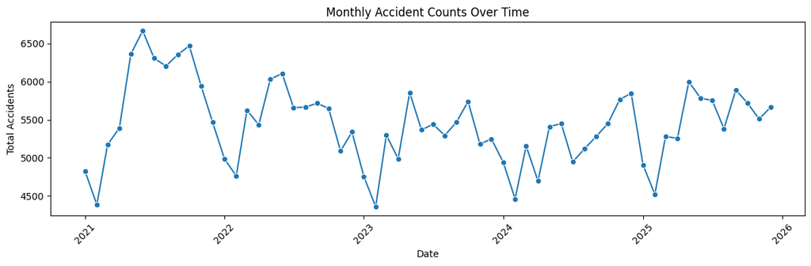

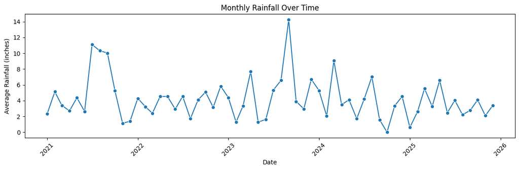

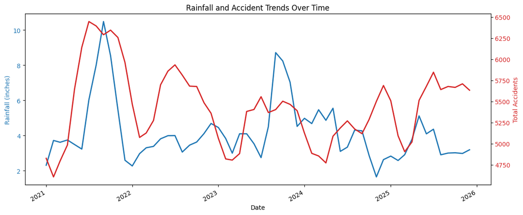

```python
# Monthly accidents over time
plt.figure(figsize=(12, 4))
sns.lineplot(data=monthly_analysis, x="Date", y="total_accidents", marker="o")
plt.title("Monthly Accident Counts Over Time")
plt.xlabel("Date")
plt.ylabel("Total Accidents")
plt.xticks(rotation=45)
plt.tight_layout()
plt.show()

# Monthly rainfall over time
plt.figure(figsize=(12, 4))
sns.lineplot(data=monthly_analysis, x="Date", y="Rainfall_inches", marker="o", color="tab:blue")
plt.title("Monthly Rainfall Over Time")
plt.xlabel("Date")
plt.ylabel("Average Rainfall (inches)")
plt.xticks(rotation=45)
plt.tight_layout()
plt.show()

# Combined trend
viz_df = monthly_analysis.sort_values("Date").copy()
viz_df["rainfall_3m_avg"] = viz_df["Rainfall_inches"].rolling(window=3, min_periods=1).mean()
viz_df["accidents_3m_avg"] = viz_df["total_accidents"].rolling(window=3, min_periods=1).mean()

fig, ax1 = plt.subplots(figsize=(12, 5))
ax1.plot(viz_df["Date"], viz_df["rainfall_3m_avg"], color="tab:blue", linewidth=2)
ax1.set_xlabel("Date")
ax1.set_ylabel("Rainfall (inches)", color="tab:blue")
ax1.tick_params(axis="y", labelcolor="tab:blue")

ax2 = ax1.twinx()
ax2.plot(viz_df["Date"], viz_df["accidents_3m_avg"], color="tab:red", linewidth=2)
ax2.set_ylabel("Total Accidents", color="tab:red")
ax2.tick_params(axis="y", labelcolor="tab:red")

plt.title("Rainfall and Accident Trends Over Time")
fig.autofmt_xdate()
plt.tight_layout()
plt.show()
```

**Interpretation:**  
The time-series visualizations show that accident counts exhibit relatively stable fluctuations over time with some seasonal variation, while rainfall displays higher variability with occasional sharp peaks. In the combined plot, there is no clear consistent pattern indicating that higher rainfall months always correspond to higher accident counts. For example, certain periods with high rainfall do not coincide with peaks in accident counts, and vice versa. This suggests that while rainfall may influence accidents in specific instances, the overall relationship between rainfall and accident counts appears weak or non-linear over time.

**Limitation:**  
The analysis is based on aggregated monthly data, which may obscure short-term relationships between rainfall and accidents (e.g., daily or hourly effects). Additionally, accident counts are influenced by multiple confounding factors such as traffic volume, time of day, and road conditions, which are not controlled for in this analysis. The use of visual inspection alone does not provide statistical evidence of association, and further analysis (e.g., correlation or hypothesis testing) is required to draw more reliable conclusions.

#### DS1 + DS2 Diagnostic Analysis: Correlation Between Rainfall and Accident Counts

**Method:** Correlation analysis, scatter plot with Pearson and Spearman correlation

**Goal:**  
To test whether months with higher rainfall tend to have higher accident counts.

**Why this method:**  
Pearson correlation is useful for checking whether there is a roughly linear relationship between rainfall and accident counts, while Spearman correlation helps detect whether a more general monotonic relationship exists even if it is not perfectly linear.

**What the code does:**  
The code plots rainfall against accident counts and computes Pearson and Spearman correlation coefficients with p-values.

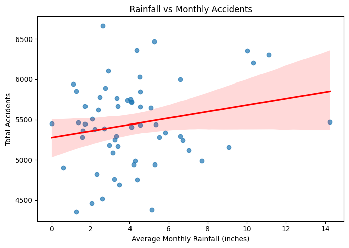

```
Pearson correlation: 0.207 (p-value = 0.1125)
Spearman correlation: 0.098 (p-value = 0.4553)
```

```python
plt.figure(figsize=(7, 5))
sns.regplot(
    data=monthly_analysis,
    x="Rainfall_inches",
    y="total_accidents",
    scatter_kws={"alpha": 0.7},
    line_kws={"color": "red"}
)
plt.title("Rainfall vs Monthly Accidents")
plt.xlabel("Average Monthly Rainfall (inches)")
plt.ylabel("Total Accidents")
plt.tight_layout()
plt.show()

pearson_corr, pearson_p = pearsonr(monthly_analysis["Rainfall_inches"], monthly_analysis["total_accidents"])
spearman_corr, spearman_p = spearmanr(monthly_analysis["Rainfall_inches"], monthly_analysis["total_accidents"])

print(f"Pearson correlation: {pearson_corr:.3f} (p-value = {pearson_p:.4f})")
print(f"Spearman correlation: {spearman_corr:.3f} (p-value = {spearman_p:.4f})")
```

**Interpretation:**  
The scatter plot and fitted regression line suggest a slight positive relationship between rainfall and monthly accident counts, where higher rainfall months tend to show marginally higher accident counts. However, the data points are quite widely dispersed, and both the Pearson (0.207) and Spearman (0.098) correlations indicate only a weak association. The high p-values further suggest that this relationship is not statistically significant. Overall, while there may be a mild upward trend, rainfall alone does not appear to be a strong predictor of accident counts.

**Limitation:**  
The analysis uses aggregated monthly data, which captures overall patterns but may smooth out short-term variations such as heavy rainfall events within a month. Additionally, the relationship is assessed using simple correlation measures, which focus on pairwise associations and may not capture more complex or indirect effects. Incorporating more granular data or additional explanatory variables could provide a more detailed understanding of the relationship.

#### DS1 + DS2 Diagnostic Analysis: Comparison of Accident Counts Between High- and Low-Rainfall Months

**Method:** Group comparison with hypothesis testing, independent two-sample t-test

**Goal:**  
To test whether accident counts differ between wetter months and drier months.

**Why this method:**  
A t-test is appropriate for comparing the mean accident counts of two groups. We split months into high-rainfall and low-rainfall groups using the median rainfall value. The grouped comparison between low-rainfall and high-rainfall months provides an additional and more interpretable way to examine whether accident counts differ meaningfully across broader rainfall conditions.

**Hypotheses:**

- **H0:** Mean accident counts are the same for high-rainfall and low-rainfall months.
- **H1:** Mean accident counts are different for high-rainfall and low-rainfall months.

**What the code does:**  
The code creates two rainfall groups, summarizes accident counts in each group, and computes the t-test statistic and p-value.

```python
test_df = monthly_analysis.copy()

median_rainfall = test_df["Rainfall_inches"].median()
test_df["rainfall_group"] = test_df["Rainfall_inches"].apply(
    lambda x: "High rainfall" if x > median_rainfall else "Low rainfall"
)

group_summary = test_df.groupby("rainfall_group")["total_accidents"].agg(["count", "mean", "std"]).reset_index()
display(group_summary)

high_group = test_df.loc[test_df["rainfall_group"] == "High rainfall", "total_accidents"]
low_group = test_df.loc[test_df["rainfall_group"] == "Low rainfall", "total_accidents"]

t_stat, p_value = ttest_ind(high_group, low_group, equal_var=False)

print(f"T-statistic: {t_stat:.3f}")
print(f"P-value: {p_value:.4f}")
print(f"Median rainfall used for grouping: {median_rainfall:.3f}")
```

|  | rainfall_group | count | mean | std |
| --- | --- | --- | --- | --- |
| 0 | High rainfall | 30 | 5534.433333 | 520.009528 |
| 1 | Low rainfall | 30 | 5360.266667 | 516.891367 |

```
T-statistic: 1.301
P-value: 0.1984
Median rainfall used for grouping: 3.690
```

**Interpretation:**  
The group comparison shows that high-rainfall months have a slightly higher mean accident count than low-rainfall months. However, the difference between the two groups is relatively small, and the t-test result (p-value = 0.1984) indicates that this difference is not statistically significant. This suggests that, based on the current grouping, there is no strong evidence that accident counts differ meaningfully between wetter and drier months.

**Limitation:**  
The grouping of months into high- and low-rainfall categories using the median provides a clear and interpretable comparison, but it simplifies rainfall into only two levels. This may not fully capture more gradual or non-linear relationships between rainfall and accident counts. Additionally, while this analysis focuses on rainfall, accident frequency may also be influenced by other factors not included here. Exploring alternative groupings or incorporating additional variables could provide further insights.

**Statistical caution:** The grouped comparison provides an interpretable way to compare lower-rainfall and higher-rainfall periods, but the result should still be interpreted carefully. The grouping step simplifies rainfall into broad categories, which can reduce detail, and monthly accident counts may also be influenced by seasonal or structural factors beyond rainfall alone. As such, the grouped comparison is best viewed as supporting evidence rather than definitive proof of a rainfall effect.

#### Critical evaluation of the result

The main DS1 + DS2 analysis suggests that rainfall alone is not a strong standalone predictor of accident counts at the monthly level. Even where the direction of association is positive, the relationship appears weak and may not be statistically strong enough to support a firm conclusion that higher monthly rainfall directly leads to more accidents.

There are several reasons for this. First, monthly aggregation may smooth out short-term weather effects that happen within specific days or hours. A heavy rainfall event may increase accident risk temporarily, but this effect can become diluted when averaged into a monthly total. Second, accident frequency is also influenced by factors not captured in the merged dataset, such as traffic volume, commuting patterns, road design, roadworks, visibility, driver behaviour, and seasonal travel effects. Third, the borough/station alignment is a practical approximation rather than a perfect physical matching of rainfall exposure for every individual crash.

For these reasons, the weak result should not be interpreted as evidence that rainfall does not matter. Rather, it suggests that monthly rainfall by itself is not sufficient to explain variation in accident counts, and that more detailed weather, traffic exposure, or event-level data would likely be needed for a stronger causal or predictive analysis.

### DS3 Analysis

The DS3 and DS4 analyses should be interpreted as supporting and contextual evidence, not as direct validation of the main DS1 + DS2 result. This is because they do not share the same exact time, location, and structure as the main merged dataset. Their role is to help explain whether rain-related accident conditions appear consistent with broader accident patterns, such as wet-road associations or severity-related context. As a result, these datasets strengthen interpretation, but they do not by themselves prove the main rainfall–accident relationship.

#### DS3 Diagnostic Analysis: Weather Condition and Road Surface Dependency

**Method:** Relationship and dependency analysis using cross-tabulation and chi-square testing

**Goal:**  
To examine whether accidents recorded under rain-related weather conditions are more likely to occur on wet road surfaces.

**Why this method:**  
Both weather conditions and road surface are categorical variables. A cross-tabulation shows how often different combinations occur, while a chi-square test checks whether the two variables are associated.

**What the code does:**  
The code groups DS3 accident records into `Rain-related` and `Not rain-related` weather categories, groups road surface into `Wet/Slippery` and `Dry/Other`, builds a contingency table, visualizes the relationship with a heatmap, and performs a chi-square test.

| Wet_Road Rain_Related | Dry / Other | Wet / Slippery |
| --- | --- | --- |
| Not rain-related | 220 | 57 |
| Rain-related | 1 | 36 |

| Wet_Road Rain_Related | Dry / Other | Wet / Slippery |
| --- | --- | --- |
| Not rain-related | 79.42 | 20.58 |
| Rain-related | 2.70 | 97.30 |

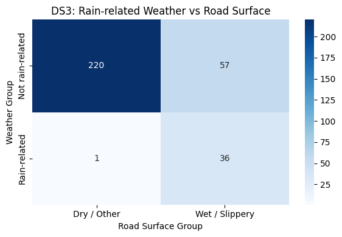

```
Chi-square statistic: 88.518
P-value: 0.0000
Degrees of freedom: 1
```

```python
import seaborn as sns
from scipy.stats import chi2_contingency

ds3_analysis = ds3_prepared.copy()

# Create rain-related weather indicator
ds3_analysis["Rain_Related"] = ds3_analysis["Weather Conditions"].astype(str).str.contains(
    "rain|drizzle|shower", case=False, na=False
)

# Create wet/slippery road indicator
ds3_analysis["Wet_Road"] = ds3_analysis["Road Surface"].astype(str).str.contains(
    "wet|snow|ice|flood", case=False, na=False
)

# Make labels clearer
ds3_analysis["Rain_Related"] = ds3_analysis["Rain_Related"].map({
    True: "Rain-related",
    False: "Not rain-related"
})
ds3_analysis["Wet_Road"] = ds3_analysis["Wet_Road"].map({
    True: "Wet / Slippery",
    False: "Dry / Other"
})

# Contingency table
ds3_ct = pd.crosstab(ds3_analysis["Rain_Related"], ds3_analysis["Wet_Road"])
display(ds3_ct)

# Row percentages
ds3_ct_pct = pd.crosstab(
    ds3_analysis["Rain_Related"],
    ds3_analysis["Wet_Road"],
    normalize="index"
) * 100
display(ds3_ct_pct.round(2))

# Heatmap
plt.figure(figsize=(6, 4))
sns.heatmap(ds3_ct, annot=True, fmt="d", cmap="Blues")
plt.title("DS3: Rain-related Weather vs Road Surface")
plt.xlabel("Road Surface Group")
plt.ylabel("Weather Group")
plt.tight_layout()
plt.show()

# Chi-square test
chi2, p_value, dof, expected = chi2_contingency(ds3_ct)

print(f"Chi-square statistic: {chi2:.3f}")
print(f"P-value: {p_value:.4f}")
print(f"Degrees of freedom: {dof}")
```

**Interpretation:**  
The contingency table and heatmap show a strong association between rain-related weather conditions and road surface conditions. Specifically, a large majority of rain-related accidents occur on wet or slippery roads (97.3%), while non-rain-related accidents are predominantly associated with dry or other road conditions (79.4%). This clear contrast suggests that rain-related weather is strongly linked to wet road surfaces. The chi-square test further supports this observation, with a very small p-value (p ≈ 0.000), indicating a statistically significant dependency between weather condition and road surface. Therefore, we can conclude that rain-related weather and wet road conditions are not independent and are highly associated.

**Limitation:**  
The analysis uses grouped categorical variables (rain-related vs non-rain-related and wet/slippery vs dry/other), which simplifies the underlying conditions into broad categories. While this improves interpretability, it may not capture more detailed variations within each category. Additionally, the chi-square test identifies association but does not imply causation. Nonetheless, the results provide strong evidence of a relationship, and further analysis incorporating additional variables could offer deeper insights into the factors contributing to accident conditions.

### DS4 Analysis

The DS3 and DS4 analyses should be interpreted as supporting and contextual evidence, not as direct validation of the main DS1 + DS2 result. This is because they do not share the same exact time, location, and structure as the main merged dataset. Their role is to help explain whether rain-related accident conditions appear consistent with broader accident patterns, such as wet-road associations or severity-related context. As a result, these datasets strengthen interpretation, but they do not by themselves prove the main rainfall–accident relationship.

#### DS4 Diagnostic Analysis: Comparison of Accident Outcomes Between Rainy and Non-Rainy Conditions

**Method:** Group comparison, visualization, and hypothesis testing

**Goal:**  
To examine whether accidents recorded under rainy conditions tend to have worse outcomes than accidents recorded under non-rainy conditions.

**Why this method:**  
DS4 includes a `Rain_Condition` indicator together with outcome variables such as injuries, fatalities, and severity score. Comparing these outcomes between rainy and non-rainy accidents helps assess whether rain-related accidents tend to be more severe.

**What the code does:**  
The code groups accidents into `Rainy` and `Non-Rainy`, compares the average injuries, fatalities, and severity score across the two groups, visualizes severity score with boxplots, and performs a t-test on severity score.

| Rain_Group | Number of Injuries count | Number of Injuries mean | Number of Injuries median | Number of Injuries std | Number of Fatalities count | Number of Fatalities mean | Number of Fatalities median | Number of Fatalities std | Severity_Score count | Severity_Score mean | Severity_Score median | Severity_Score std |
| --- | --- | --- | --- | --- | --- | --- | --- | --- | --- | --- | --- | --- |
| Non-Rainy | 105438 | 9.511495 | 9.0 | 5.776576 | 105438 | 1.993513 | 2.0 | 1.414594 | 105438 | 2.332537 | 2.0 | 1.246411 |
| Rainy | 26562 | 9.495143 | 9.0 | 5.765676 | 26562 | 2.003087 | 2.0 | 1.406522 | 26562 | 2.329230 | 2.0 | 1.249432 |

|  | Rain_Group | Number of Injuries | Number of Fatalities | Severity_Score |
| --- | --- | --- | --- | --- |
| 0 | Non-Rainy | 9.511495 | 1.993513 | 2.332537 |
| 1 | Rainy | 9.495143 | 2.003087 | 2.329230 |

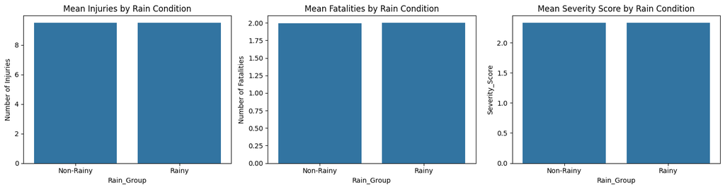

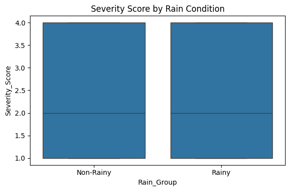

```
T-statistic: -0.386
P-value: 0.6997
```

```python
from scipy.stats import ttest_ind

ds4_support = ds4_prepared.copy()

# Create readable rain-condition labels
ds4_support["Rain_Group"] = ds4_support["Rain_Condition"].map({
    1: "Rainy",
    0: "Non-Rainy"
})

# Summary statistics by rain condition
ds4_rain_summary = (
    ds4_support.groupby("Rain_Group")[["Number of Injuries", "Number of Fatalities", "Severity_Score"]]
    .agg(["count", "mean", "median", "std"])
)

display(ds4_rain_summary)

# Bar chart of mean outcomes
mean_summary = (
    ds4_support.groupby("Rain_Group")[["Number of Injuries", "Number of Fatalities", "Severity_Score"]]
    .mean()
    .reset_index()
)

display(mean_summary)

fig, axes = plt.subplots(1, 3, figsize=(15, 4))

sns.barplot(data=mean_summary, x="Rain_Group", y="Number of Injuries", ax=axes[0])
axes[0].set_title("Mean Injuries by Rain Condition")

sns.barplot(data=mean_summary, x="Rain_Group", y="Number of Fatalities", ax=axes[1])
axes[1].set_title("Mean Fatalities by Rain Condition")

sns.barplot(data=mean_summary, x="Rain_Group", y="Severity_Score", ax=axes[2])
axes[2].set_title("Mean Severity Score by Rain Condition")

plt.tight_layout()
plt.show()

# Boxplot for severity
plt.figure(figsize=(6, 4))
sns.boxplot(data=ds4_support, x="Rain_Group", y="Severity_Score")
plt.title("Severity Score by Rain Condition")
plt.tight_layout()
plt.show()

# Hypothesis test on severity score
rainy_severity = ds4_support.loc[ds4_support["Rain_Group"] == "Rainy", "Severity_Score"]
non_rainy_severity = ds4_support.loc[ds4_support["Rain_Group"] == "Non-Rainy", "Severity_Score"]

t_stat, p_value = ttest_ind(rainy_severity, non_rainy_severity, equal_var=False)

print(f"T-statistic: {t_stat:.3f}")
print(f"P-value: {p_value:.4f}")
```

**Interpretation:**  
The group comparison shows that accidents under rainy and non-rainy conditions have very similar outcomes in terms of injuries, fatalities, and severity score. The mean number of injuries is slightly lower in rainy conditions, while fatalities are marginally higher, but the differences are minimal overall. The boxplot further confirms that the distribution of severity scores is nearly identical for both groups, with similar medians and ranges. The t-test result (p-value = 0.6997) indicates that there is no statistically significant difference in severity scores between rainy and non-rainy accidents. Overall, this suggests that rain alone does not appear to substantially affect accident severity.

**Limitation:**  
The analysis compares outcomes based on a binary classification of rain conditions, which simplifies weather into two broad categories and may not capture differences in rainfall intensity or duration. Additionally, while severity is summarized using a numerical score, this representation may not fully reflect all aspects of accident impact. The analysis focuses on direct comparisons between two groups and does not account for other contributing factors such as road conditions or traffic patterns. Incorporating additional variables or more detailed weather information could provide a more nuanced understanding of accident severity.

#### DS4 Diagnostic Analysis: Accident Severity Under Rain and Road Condition Combinations

**Method:** Grouped comparison

**Goal:**  
To examine whether rainy accidents on poorer road conditions tend to have worse outcomes.

**Why this method:**  
Rain may be more dangerous when combined with wet, icy, or snow-covered roads. Comparing severity across these grouped conditions gives more useful supporting evidence than looking at rain alone.

**What the code does:**  
The code creates a grouped road-condition variable, compares severity score across rainy and non-rainy accidents, and visualizes the average severity score for each combination.

|  | Rain_Group | Road_Group | count | mean | median | std |
| --- | --- | --- | --- | --- | --- | --- |
| 0 | Non-Rainy | Other road condition | 26270 | 2.329387 | 2.0 | 1.246699 |
| 1 | Non-Rainy | Poor road condition | 79168 | 2.333582 | 2.0 | 1.246321 |
| 2 | Rainy | Other road condition | 6585 | 2.327411 | 2.0 | 1.246508 |
| 3 | Rainy | Poor road condition | 19977 | 2.329829 | 2.0 | 1.250426 |

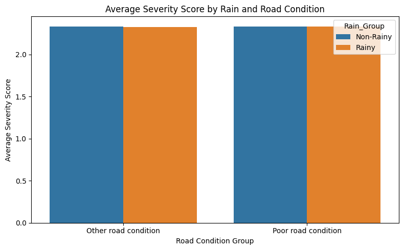

```python
ds4_road = ds4_prepared.copy()

ds4_road["Rain_Group"] = ds4_road["Rain_Condition"].map({
    1: "Rainy",
    0: "Non-Rainy"
})

# Group road conditions into simpler categories
ds4_road["Road_Group"] = ds4_road["Road Condition"].astype(str).apply(
    lambda x: "Poor road condition" if any(term in x.lower() for term in ["wet", "icy", "snow", "flood"])
    else "Other road condition"
)

road_rain_summary = (
    ds4_road.groupby(["Rain_Group", "Road_Group"])["Severity_Score"]
    .agg(["count", "mean", "median", "std"])
    .reset_index()
)

display(road_rain_summary)

plt.figure(figsize=(8, 5))
sns.barplot(data=road_rain_summary, x="Road_Group", y="mean", hue="Rain_Group")
plt.title("Average Severity Score by Rain and Road Condition")
plt.xlabel("Road Condition Group")
plt.ylabel("Average Severity Score")
plt.tight_layout()
plt.show()
```

**Interpretation:**  
The grouped comparison shows that average severity scores are very similar across all combinations of rain condition and road condition. While accidents on poorer road conditions exhibit slightly higher severity scores than those on other road conditions, the differences are minimal. Additionally, the severity scores under rainy and non-rainy conditions are nearly identical within each road condition group. This suggests that neither rain condition nor road condition alone, nor their combination, has a strong impact on accident severity. Overall, there is no clear interaction effect between rain and road condition on severity based on the observed averages.

**Limitation:**  
The analysis relies on grouped averages, which provide a clear summary but may not capture variability within each group. The categorization of road conditions into broad groups (e.g., “poor” vs “other”) simplifies the underlying data and may overlook more detailed differences. Additionally, while this comparison highlights general patterns, it does not include formal statistical testing to evaluate the significance of differences between groups. Extending the analysis with more detailed categories or statistical tests could provide deeper insight into potential interaction effects.

## Presentation of main results (Share)

These visualisations were selected to complement the main analysis by providing a clear and interpretable narrative across three dimensions: when accidents occur, how rain-related conditions affect road safety, and what underlying factors contribute most to accident severity. While the main DS1 + DS2 analysis focuses on the direct relationship between rainfall and accident counts, these supporting visuals help explain the broader risk pattern and make the findings more actionable for stakeholders.

### Stakeholders

The main stakeholders for this project are MTA planners, road safety agencies, and traffic management teams in New York. They need findings that are not only visually clear, but also directly tied to the analyses conducted in this project so that decisions can be justified using data.

### Visualisation

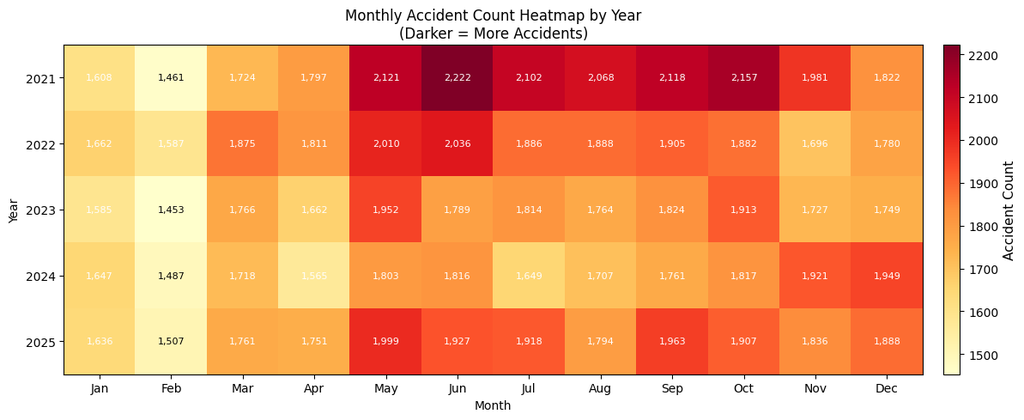

```python
import pandas as pd
import matplotlib.pyplot as plt
import numpy as np

# Step 1: Average total_accidents across the 3 stations per month
# (since each month appears 3 times — once per station)
merged_avg = merged.groupby(['Year', 'Month'])['total_accidents'].mean().reset_index()

#Step 2: Pivot into Year x Month grid
pivot = merged_avg.pivot(index='Year', columns='Month', values='total_accidents')

month_names = ['Jan','Feb','Mar','Apr','May','Jun',
               'Jul','Aug','Sep','Oct','Nov','Dec']
pivot.columns = month_names

#Step 3: Plot heatmap
fig, ax = plt.subplots(figsize=(13, 5))

im = ax.imshow(pivot.values, cmap='YlOrRd', aspect='auto')

# axis ticks
ax.set_xticks(range(12))
ax.set_xticklabels(month_names)
ax.set_yticks(range(len(pivot.index)))
ax.set_yticklabels(pivot.index.astype(int))

# annotate each cell with the accident count
for i in range(len(pivot.index)):
    for j in range(12):
        val = pivot.values[i, j]
        if not np.isnan(val):
            ax.text(j, i, f'{int(val):,}',
                    ha='center', va='center',
                    fontsize=8,
                    color='black' if val < pivot.values.max() * 0.7 else 'white')

# colourbar
cbar = plt.colorbar(im, ax=ax, pad=0.02)
cbar.set_label('Accident Count', fontsize=11)

ax.set_title('Monthly Accident Count Heatmap by Year\n(Darker = More Accidents)')
ax.set_xlabel('Month')
ax.set_ylabel('Year')

plt.tight_layout()
plt.savefig('heatmap_year_month.png', dpi=150)
plt.show()
```

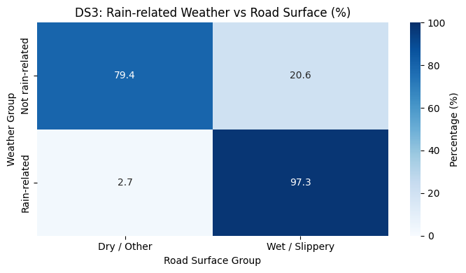

```python
plt.figure(figsize=(7, 4))
sns.heatmap( ds3_ct_pct, annot=True,fmt='.1f',cmap='Blues',cbar_kws={'label': 'Percentage (%)'},vmin=0, vmax=100                    )
plt.title('DS3: Rain-related Weather vs Road Surface (%)')
plt.xlabel('Road Surface Group')
plt.ylabel('Weather Group')
plt.tight_layout()
plt.show()
```

This heatmap gives a sharper explanation of why rain matters. When weather is rain-related, 97% of accidents occur on wet/slippery roads. Under non-rain related weather, it is only 21%. This confirms that rainfall directly translates into hazardous road surfaces. While the main merged analysis found that rainfall alone has only a weak direct relationship with accident counts, this DS3 analysis explains how rain may still matter operationally: rainfall appears to translate into hazardous wet-road conditions, which then increase road safety risk.

For stakeholders, this means the project’s findings should not be read as “rain does not matter,” but rather as “rain matters mainly through the dangerous driving conditions it creates.” This justifies interventions focused on road-surface safety, drainage, and wet-weather hazard warnings.

|  | Rain_Group | Road_Group | count |
| --- | --- | --- | --- |
| 0 | Non-Rainy | Other road condition | 26270 |
| 1 | Non-Rainy | Poor road condition | 79168 |
| 2 | Rainy | Other road condition | 6585 |
| 3 | Rainy | Poor road condition | 19977 |

[figure not shown]

```python
ds4_road = ds4_prepared.copy()

ds4_road["Rain_Group"] = ds4_road["Rain_Condition"].map({
    1: "Rainy",
    0: "Non-Rainy"
})

# Group road conditions into simpler categories
ds4_road["Road_Group"] = ds4_road["Road Condition"].astype(str).apply(
    lambda x: "Poor road condition" if any(term in x.lower() for term in ["wet", "icy", "snow", "flood"])
    else "Other road condition"
)

road_rain_summary = (
    ds4_road.groupby(["Rain_Group", "Road_Group"])
    .size()
    .reset_index(name="count")
)

display(road_rain_summary)

plt.figure(figsize=(8, 5))
sns.barplot(data=road_rain_summary, x="Road_Group", y="count", hue="Rain_Group")
plt.title("Average Severity Score by Rain and Road Condition")
plt.xlabel("Road Condition Group")
plt.ylabel("Count")
plt.tight_layout()
plt.show()
```

## Possible actions based on results (Act)

Based on the three visualisations and supporting analyses, the findings suggest that accident risk is shaped not just by rainfall alone, but by the combination of rain-related wet/slippery road conditions and poor road surface quality. Together, these factors point to several actions that MTA can take to reduce accident risk.

Operational actions: Since the DS3 analysis shows that 97% of rain-related accidents occur on wet/slippery roads, MTA can implement targeted wet-weather risk responses the moment rain is detected. This includes triggering electronic signboard warnings on roads and highways, issuing wet-weather driving advisories, and partnering with navigation platforms such as Waze or Google Maps to flag high-risk road segments in real time. The goal is to warn drivers early and reduce exposure during hazardous road conditions.

Long term strategic change: MTA can integrate rainfall, accident, and road condition data into a real-time risk dashboard within broader Smart City systems. This would allow traffic control centres to identify high-risk periods and locations earlier, plan interventions before peak-risk months, and manage road hazards more proactively rather than reacting only after accidents occur.

## Final Reflection

### Considerations on data ethics

Data ethics: Missing values were encountered during the project. From an ethics standpoint, how missing data is handled matters. We dropped missing values which introduces bias that can affect conclusions. It is important to be transparent about what method was used and why, and to acknowledge that missing accident records for certain months or boroughs may mean that some incidents are underrepresented in the analysis. This should be stated as a limitation when presenting findings to MTA, so decision-makers do not over-generalise the results.

### Considerations on data privacy and security

Data privacy: No personal details were recorded in the datasets used, such as driver names, vehicle plates, or individual identifiers. This significantly reduces privacy risk. However, it is still worth noting that collision IDs and borough-level location data, while not personally identifiable on their own, could theoretically be cross-referenced with external datasets to re-identify individuals involved in specific incidents,known as the re-identification risk. In this project, since analysis was aggregated to the monthly level, this risk was effectively eliminated.

Data Security: DS1 and DS2 were obtained from authoritative public sources, hence the integrity and security of the data at the point of collection can be reasonably trusted, as these institutions maintain established data security standards.

However DS3 and DS4 are obtained from third party websites (Kaggle), which means there is a probability it may have undergone undocumented transformations before publication, this introduces potential risks to data integrity and reproducibility.

For the purpose of a school project, such datasets can still be used as supporting evidence, but in a professional context, source verification would be mandatory. Hence it would be a better practice to source from government websites to ensure full tracebility.